# 1. Problem

The problem addressed in this dataset revolves around understanding and uncovering novel insights about the progression of Hepatitis C Virus (HCV) in Egyptian patients.

What to Solve:

-Classify Patients: Develop a classification model to categorize HCV patients based on various attributes and factors present in the dataset. This helps in understanding the diverse manifestations and progressions of the disease in different individuals.

-Cluster Patients: Utilize clustering techniques to identify groups of patients with similar characteristics. This clustering can assist in the development of personalized treatment strategies, improving disease management and healthcare outcomes.

-Extract Knowledge: Apply data mining techniques to extract hidden patterns, and valuable insights from the dataset. This knowledge discovery process aims to uncover information that may not be immediately apparent through conventional analysis.

Why It Is Important:

-Medical Understanding: Hepatitis C is a significant public health issue, and its understanding is crucial for effective management and treatment. By classifying patients, researchers and healthcare professionals can identify commonalities and differences in disease progression, leading to a deeper understanding of the virus’s impact on individuals.

-Advancements in Research: The project contributes to the broader field of medical research by using data mining techniques to uncover novel insights. This knowledge can inform future studies, guide research directions, and contribute to the development of more targeted and effective healthcare interventions.

-Public Health Impact: Given the relatively high prevalence of HCV in Egypt, the outcomes of this project can have a direct impact on public health in the region. Improved understanding and personalized approaches to treatment can contribute to better management of the disease and potentially reduce its overall burden on the healthcare system.

# 2.Data Mining Tasks:

1.Classification Task:

Class Attribute: Baseline Histological Staging

This attribute represents the stage of baseline histological severity in HCV patients. It has four stages, indicating the severity of liver histopathology.

Goals of Classification:

Predictive Modeling: Develop a classification model to predict the baseline histological staging of HCV patients based on the given attributes (features) in the dataset.

Patient Stratification: Classify patients into one of the four stages of baseline histological severity, providing insights into the progression of the disease in different individuals.

Feature Importance: Identify the most significant features contributing to the classification of patients into different histological stages.

2.Clustering Task:

Goals of Clustering:

Group Similar Patients: Apply clustering techniques to group patients with similar characteristics, identifying natural clusters within the dataset.

Personalized Treatment Strategies: Uncover patient clusters that share common traits, helping in the development of personalized treatment strategies for specific patient groups.

Discover Hidden Patterns: Extract hidden patterns in patient data that might not be immediately apparent, providing insights into the heterogeneity of HCV patients.

Enhance Disease Understanding: Clustering can reveal subgroups with unique characteristics, contributing to a more nuanced understanding of HCV progression in Egyptian patients.

# Goal of Collecting this Dataset

The goal of collecting a Hepatitis C Virus (HCV) dataset To uncover novel knowledge and insights about HCV in Egyptian patients that may not be immediately apparent by understanding the progress of HCV in infected individuals. Data mining plays an essential role in the knowledge discovery process techniques which can be used to analyze how the disease evolves over time and what factors contribute to its progression.

# 3.Data

The dataset was sourced from the uci website in this URL : http://archive.ics.uci.edu/dataset/503/hepatitis+c+virus+hcv+for+egyptian+patients

# General Information

- Number of Attributes: 28

- Number of Objects: 1385

- Type of Attributes: Numeric, Nominal,Ordinal

-The goal of collecting a Hepatitis C Virus (HCV) dataset is to uncover novel knowledge and insights about HCV in Egyptian patients that may not be immediately apparent. This dataset serves a dual purpose: First, it allows us to classify patients into different categories based on various factors, providing a deeper understanding of the disease’s progression and its impact on individuals. Second, through clustering techniques, we aim to identify distinct patient groups with similar characteristics, allowing for the development of personalized treatment strategies and better disease management. Data mining techniques play an essential role in the knowledge discovery process, helping us analyze the disease’s evolution over time and determine the factors contributing to its progression and impact on different patient groups

- Features names:Age,Gender,BMI(Body Mass Index),Nausea/Vomting, Diarrhea, Fever, Headache,Fatigue & generalized bone ache, Jaundice, Epigastric pain, WBC(White blood cells),RBC(Red blood cells),HGB(Hemoglobin),Plat(Platelets), AST 1(aspartate transaminase ratio),ALT1(alanine transaminase ratio 1 week),ALT4(alanine transaminase ratio 4 weeks), ALT 12(alanine transaminase ratio 12 weeks), ALT 24(alanine transaminase ratio 24 weeks), ALT 36(alanine transaminase ratio 36 weeks ),ALT 48(alanine transaminase ratio 48 weeks), ALT after 24 w(after 24 warnings alanine transaminase ratio 24 weeks), RNA Base, RNA 4, RNA 12, RNA EOT(RNA end-of-treatment),RNA EF(RNA Elongation Factor), Baseline histological Grading, Baselinehistological staging.

```r
# Install and load necessary packages
dataset <- read.csv('HCV-Egy-Data.csv')


# Install and load necessary packages
if(!require(Hmisc)){
 install.packages("Hmisc")  # Install the Hmisc package
    }
library("Hmisc")    # Load the Hmisc package
```

```r
 describe(dataset)
```

```
## dataset
##
##  29  Variables      1385  Observations
## --------------------------------------------------------------------------------
## Age
##        n  missing distinct     Info     Mean      Gmd      .05      .10
##     1385        0       30    0.999    46.32    10.14       33       34
##      .25      .50      .75      .90      .95
##       39       46       54       58       60
##
## lowest : 32 33 34 35 36, highest: 57 58 59 60 61
## --------------------------------------------------------------------------------
## Gender
##        n  missing distinct     Info     Mean      Gmd
##     1385        0        2     0.75     1.49   0.5001
##
## Value         1    2
## Frequency   707  678
## Proportion 0.51 0.49
## --------------------------------------------------------------------------------
## BMI
##        n  missing distinct     Info     Mean      Gmd      .05      .10
##     1385        0       14    0.995    28.61    4.695       22       23
##      .25      .50      .75      .90      .95
##       25       29       32       34       35
##
## Value         22    23    24    25    26    27    28    29    30    31    32
## Frequency     96    97   112    92    78    99   107    93    95   104    90
## Proportion 0.069 0.070 0.081 0.066 0.056 0.071 0.077 0.067 0.069 0.075 0.065
##
## Value         33    34    35
## Frequency    104   118   100
## Proportion 0.075 0.085 0.072
##
## For the frequency table, variable is rounded to the nearest 0
## --------------------------------------------------------------------------------
## Fever
##        n  missing distinct     Info     Mean      Gmd
##     1385        0        2    0.749    1.516   0.4999
##
```

[output cut: 205 more lines]

```
## Frequency    106   139    86
## Proportion 0.077 0.100 0.062
##
## For the frequency table, variable is rounded to the nearest 0
## --------------------------------------------------------------------------------
## Baselinehistological.staging
##        n  missing distinct     Info     Mean      Gmd
##     1385        0        4    0.937    2.536    1.254
##
## Value          1     2     3     4
## Frequency    336   332   355   362
## Proportion 0.243 0.240 0.256 0.261
##
## For the frequency table, variable is rounded to the nearest 0
## --------------------------------------------------------------------------------
```

# Data Structure

the function str will help to understand the internal structure of the project Data name, variables and objects numbers, Dimension, Data Values (provided a preview of the first few data values for each variable)

```r
# Explore dataset structure
str(dataset)
```

```
## 'data.frame':    1385 obs. of  29 variables:
##  $ Age                            : int  56 46 57 49 59 58 42 48 44 45 ...
##  $ Gender                         : int  1 1 1 2 1 2 2 2 1 1 ...
##  $ BMI                            : int  35 29 33 33 32 22 26 30 23 30 ...
##  $ Fever                          : int  2 1 2 1 1 2 1 1 1 2 ...
##  $ Nausea.Vomting                 : int  1 2 2 2 1 2 1 1 1 1 ...
##  $ Headache                       : int  1 2 2 1 2 2 2 2 2 2 ...
##  $ Diarrhea                       : int  1 1 2 2 1 1 2 2 2 2 ...
##  $ Fatigue...generalized.bone.ache: int  2 2 1 1 2 2 2 1 2 1 ...
##  $ Jaundice                       : int  2 2 1 2 2 2 2 1 1 1 ...
##  $ Epigastric.pain                : int  2 1 1 1 2 1 2 2 2 2 ...
##  $ WBC                            : int  7425 12101 4178 6490 3661 11785 11620 7335 10480 6681 ...
##  $ RBC                            : num  4248807 4429425 4621191 4794631 4606375 ...
##  $ HGB                            : int  14 10 12 10 11 15 12 11 12 12 ...
##  $ Plat                           : num  112132 129367 151522 146457 187684 ...
##  $ AST.1                          : int  99 91 113 43 99 66 78 119 93 55 ...
##  $ ALT.1                          : int  84 123 49 64 104 104 57 112 83 68 ...
##  $ ALT4                           : num  52 95 95 109 67 121 113 80 55 72 ...
##  $ ALT.12                         : int  109 75 107 80 48 96 118 127 102 127 ...
##  $ ALT.24                         : int  81 113 116 88 120 65 107 45 97 81 ...
##  $ ALT.36                         : int  5 57 5 48 94 73 84 96 122 125 ...
##  $ ALT.48                         : int  5 123 5 77 90 114 80 53 39 43 ...
##  $ ALT.after.24.w                 : int  5 44 5 33 30 29 28 39 45 30 ...
##  $ RNA.Base                       : int  655330 40620 571148 1041941 660410 1157452 325694 641129 591441 1151206 ...
##  $ RNA.4                          : int  634536 538635 661346 449939 738756 1086852 1034008 72050 757361 230488 ...
##  $ RNA.12                         : int  288194 637056 5 585688 3731527 5 275095 787295 5 267320 ...
##  $ RNA.EOT                        : int  5 336804 735945 744463 338946 5 214566 370605 371090 275295 ...
##  $ RNA.EF                         : int  5 31085 558829 582301 242861 5 635157 506296 203042 555516 ...
##  $ Baseline.histological.Grading  : int  13 4 4 10 11 4 12 12 5 4 ...
##  $ Baselinehistological.staging   : int  2 2 4 3 1 4 4 3 2 2 ...
```

#Snapshot of Raw Dataset: Below is a snapshot of the raw dataset:

```r
head(dataset)
```

```
##   Age Gender BMI Fever Nausea.Vomting Headache Diarrhea
## 1  56      1  35     2              1        1        1
## 2  46      1  29     1              2        2        1
## 3  57      1  33     2              2        2        2
## 4  49      2  33     1              2        1        2
## 5  59      1  32     1              1        2        1
## 6  58      2  22     2              2        2        1
##   Fatigue...generalized.bone.ache Jaundice Epigastric.pain   WBC     RBC HGB
## 1                               2        2               2  7425 4248807  14
## 2                               2        2               1 12101 4429425  10
## 3                               1        1               1  4178 4621191  12
## 4                               1        2               1  6490 4794631  10
## 5                               2        2               2  3661 4606375  11
## 6                               2        2               1 11785 3882456  15
##     Plat AST.1 ALT.1 ALT4 ALT.12 ALT.24 ALT.36 ALT.48 ALT.after.24.w RNA.Base
```

[output cut: 20 more lines]

```r
# Check for missing values
sum(is.na(dataset))
```

```
## [1] 0
```

No missing values in the data set

# Summary statistics

we choose three variables to show the Summary statistics for which (Age, Body mass index,RNA end-of-treatment )

```r
# Summary statistics for numerical variables
summary(dataset[c("Age", "BMI", "RNA.EOT")])
```

```
##       Age             BMI           RNA.EOT
##  Min.   :32.00   Min.   :22.00   Min.   :     5
##  1st Qu.:39.00   1st Qu.:25.00   1st Qu.:     5
##  Median :46.00   Median :29.00   Median :251376
##  Mean   :46.32   Mean   :28.61   Mean   :287660
##  3rd Qu.:54.00   3rd Qu.:32.00   3rd Qu.:517806
##  Max.   :61.00   Max.   :35.00   Max.   :808450
```

These statistics shows that for ‘Age’ : -The minimum infected age is 32 years. -The median age (50th percentile) is 46 years, meaning that 50% of the individuals are 46 years old or younger. -The mean age is approximately 46.32 years, providing the average age in the dataset. -The maximum age is 61 years, representing the oldest age in the dataset

for ‘BMI’ : -The minimum BMI is 22.

-The median BMI is 29, indicating that 50% of the individuals have a BMI of 29 or lower. -The mean BMI is approximately 28.61, providing the average BMI in the dataset.

-The maximum BMI is 35, representing the highest BMI in the dataset

for ‘RNA’ : -The minimum HCV RNA level at the end of treatment is 5.

-The median HCV RNA level is 251,376, meaning that 50% of the individuals have an HCV RNA level of 251,376 or lower at the end of treatment. -The mean HCV RNA level is approximately 287,660, providing the average HCV RNA level at the end of treatment.

-The maximum HCV RNA level at the end of treatment is 808,450, representing the highest value in the dataset.

# Class Label

The class label “Baselinehistological.staging” categorizes patients into four distinct stages, each representing a different level of the condition under study. These stages provide valuable insights into the distribution of patients across the disease’s progression. The pie chart below illustrates the distribution of patients among these stages:

```r
if(!require(vcd)){
 install.packages("vcd")  # Install the Hmisc package
    }
if(!require(grid)){
 install.packages("grid")  # Install the Hmisc package
    }
```

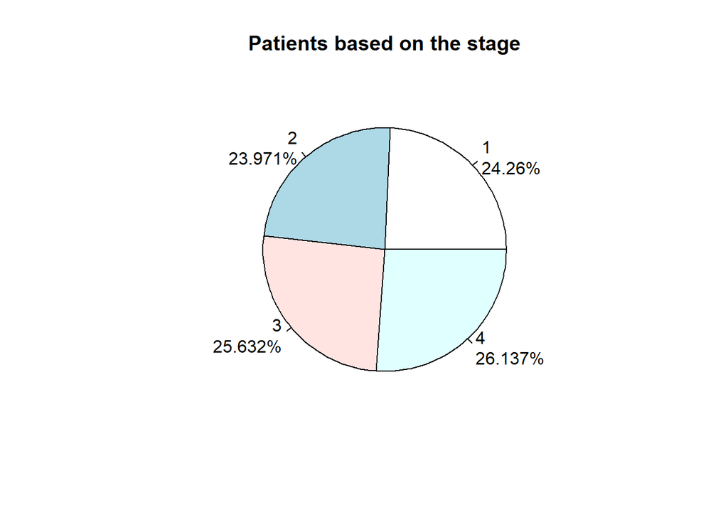

```r
# Read the data from the CSV file
data <-read.csv('HCV-Egy-Data.csv')


# Create the contingency table
contingency_table <- table(data$Baselinehistological.staging)

# Calculate percentages
percentages <- prop.table(contingency_table) * 100

# Round percentages to 3 decimal places
percentages <- round(percentages, 3)

# Create labels for the pie chart
labels <- paste0(names(contingency_table), '\n', percentages, '%')


# Create the pie chart
pie(contingency_table, labels = labels, main = "Patients based on the stage")
```

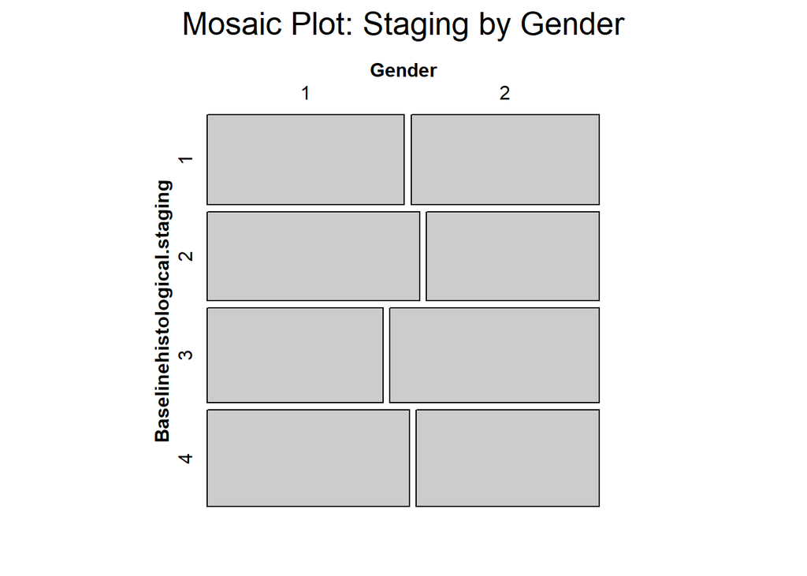

```r
# Load necessary libraries
library(vcd)

# Create a mosaic plot for 'Baselinehistological.staging' by 'Gender'
mosaic(~ Baselinehistological.staging + Gender, data = dataset, main = "Mosaic Plot: Staging by Gender")
```

Furthermore;

In the mosaic plot depicting the relationship between ‘Baselinehistological.staging’ and ‘Gender,’ we observe a difference in the diagnosis patterns between men and women, particularly in stages 2 and 3.

#plotting methods

a-Histogram for ‘Age’

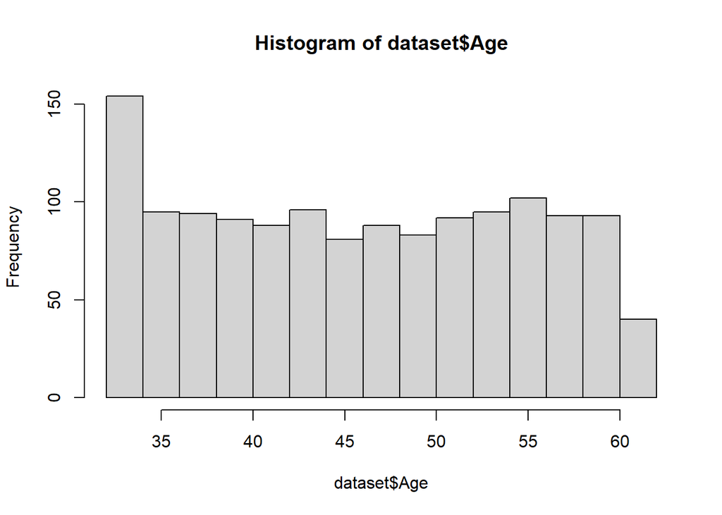

```r
# Histogram for a numerical variable 'Age'
hist(dataset$Age)
```

shows that a peak in HCV virus infections among individuals aged 32 to 35, indicates that this specific age group is more susceptible to the virus.and comes after them who aged 53 to 55.

b-Boxplot for ‘Age’ by ‘Gender’

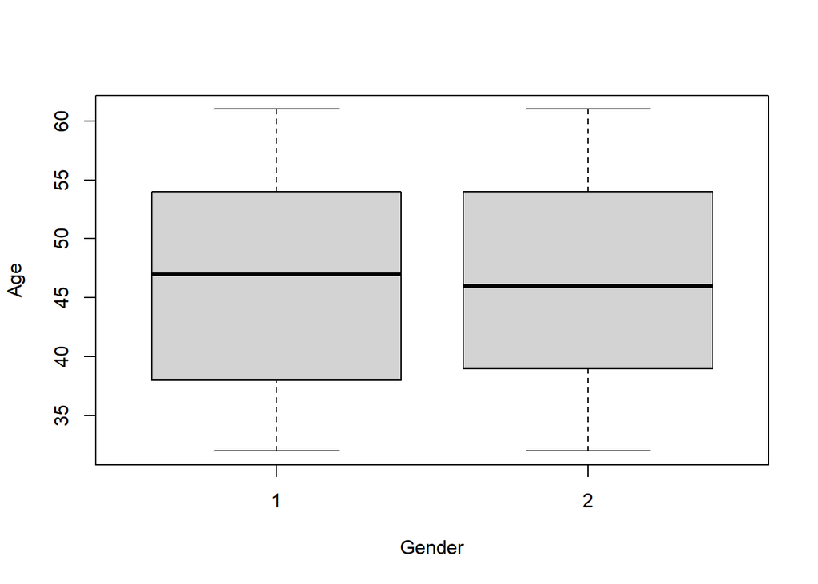

```r
boxplot(Age ~ Gender, data = dataset)
```

```r
if(!require(dplyr)){
 install.packages("dplyr")  # Install the dplyr package
    }
library("dplyr")    # Load the dplyr package
```

c-pie chart that shows patients who were suffering from Headache

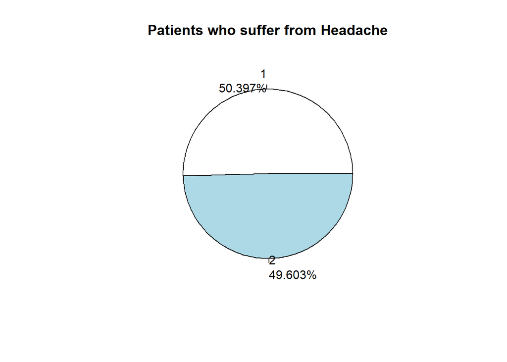

```r
# Read the data from the CSV file
data <-read.csv('HCV-Egy-Data.csv')


# Create the contingency table
contingency_table <- table(data$Headache)


# Calculate percentages
percentages <- prop.table(contingency_table) * 100

# Round percentages to 3 decimal places
percentages <- round(percentages, 3)

# Create labels for the pie chart
labels <- paste0(names(contingency_table), '\n', percentages, '%')

# Create the pie chart
pie(contingency_table, labels = labels, main = "Patients who suffer from Headache")
```

d-pie chart that shows patients who were suffering from Fever

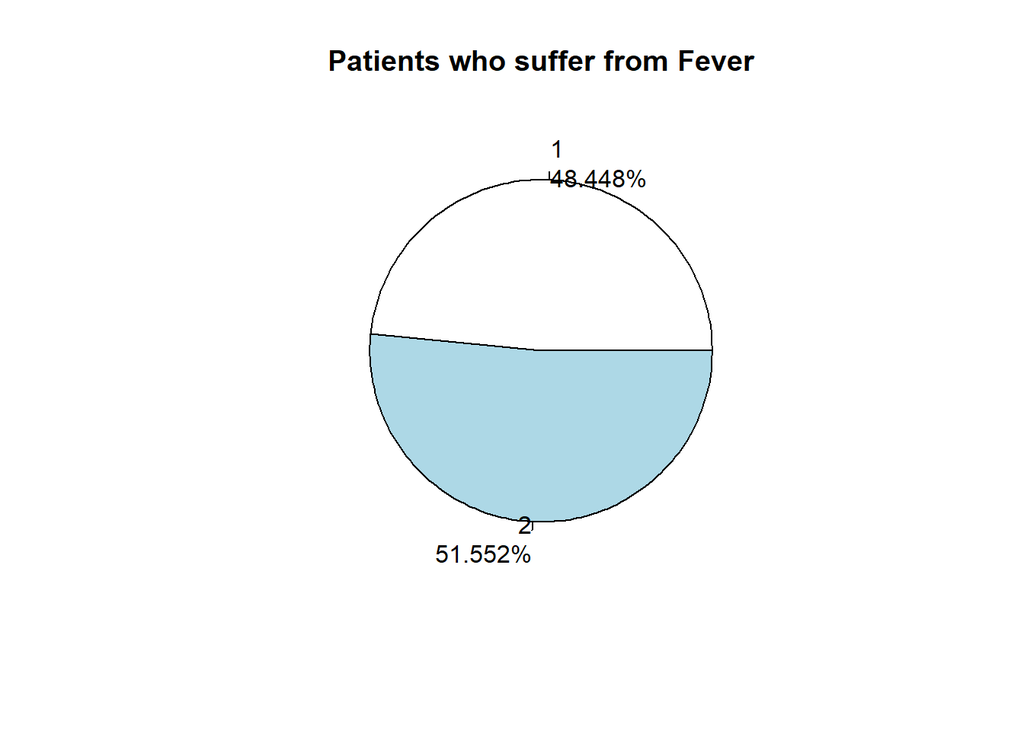

```r
# Read the data from the CSV file
data <-read.csv('HCV-Egy-Data.csv')

# Create a table of the 'Fever' column
tab <- table(data$Fever)

# Calculate percentages
percentages <- prop.table(tab) * 100

# Round percentages to 3 decimal places
percentages <- round(percentages, 3)

# Create labels for the pie chart
labels <- paste0(names(tab), '\n', percentages, '%')

# Create the pie chart
pie(tab, labels = labels, main = "Patients who suffer from Fever")
```

it’s evident that 50% of individuals infected with HCV are experiencing headaches. Additionally, the data reveals that 51.5% of individuals infected by the virus are experiencing fever. This high percentage indicates that both fever and headache are common symptoms associated with HCV infection

```r
# Print the dimensions of the dataset
dim(dataset)
```

```
## [1] 1385   29
```

```r
# Remove rows with missing values and print new dimensions
dataset = na.omit(dataset)
dim(dataset)
```

```
## [1] 1385   29
```

#Detecting outliers using boxplots

Outliers in a database are data points that stand out from the rest and don’t follow the usual pattern. They can cause problems in data analysis by making the results inaccurate or misleading. First, we identify all outliers for the numeric columns. Second, we deleted rows containing outliers. In our database we have 4 rows containing outliers.

```r
# Checking for outliers in various columns
boxplot.stats(dataset$Age)$out
```

```
## integer(0)
```

```r
boxplot.stats(dataset$BMI)$out
```

```
## integer(0)
```

```r
boxplot.stats(dataset$WBC)$out
```

```
## integer(0)
```

```r
boxplot.stats(dataset$RBC)$out
```

```
## numeric(0)
```

```r
boxplot.stats(dataset$HGB)$out
```

```
## integer(0)
```

```r
boxplot.stats(dataset$Plat)$out
```

```
## numeric(0)
```

```r
boxplot.stats(dataset$AST.1)$out
```

```
## integer(0)
```

```r
boxplot.stats(dataset$ALT.1)$out
```

```
## integer(0)
```

```r
boxplot.stats(dataset$ALT4)$out
```

```
## numeric(0)
```

```r
boxplot.stats(dataset$ALT.12)$out
```

```
## integer(0)
```

```r
boxplot.stats(dataset$ALT.24)$out
```

```
## integer(0)
```

```r
boxplot.stats(dataset$ALT.36)$out
```

```
## integer(0)
```

```r
boxplot.stats(dataset$ALT.48)$out
```

```
## integer(0)
```

```r
boxplot.stats(dataset$ALT.after.24.w)$out
```

```
## [1] 5 5 5
```

```r
boxplot.stats(dataset$RNA.Base)$out
```

```
## integer(0)
```

```r
boxplot.stats(dataset$RNA.4)$out
```

```
## integer(0)
```

```r
boxplot.stats(dataset$RNA.12)$out
```

```
## [1] 3731527
```

```r
boxplot.stats(dataset$RNA.EOT)$out
```

```
## integer(0)
```

```r
boxplot.stats(dataset$RNA.EF)$out
```

```
## integer(0)
```

```r
boxplot.stats(dataset$Baseline.histological.Grading)$out
```

```
## integer(0)
```

the information provided by these plots suggests that certain symptoms, age distributions, and disease staging may require careful scrutiny. High prevalence rates, differences between genders, or the presence of outliers can indicate data quality issues. Data preprocessing steps like handling missing values, addressing outliers, and ensuring data consistency may be necessary to enhance the reliability of the dataset for subsequent data mining tasks.

# 4.Data Preprocessing:

```r
# Removing outliers
# Remove outliers in the 'ALT.after.24.w' column
outliers <- boxplot(dataset$ALT.after.24.w, plot = FALSE)$out
dataset <- dataset[-which(dataset$ALT.after.24.w %in% outliers), ]
boxplot.stats(dataset$ALT.after.24.w)$out
```

```
## integer(0)
```

```r
# Remove outliers in the 'RNA.12' column
outliers <- boxplot(dataset$RNA.12, plot = FALSE)$out
dataset <- dataset[-which(dataset$RNA.12 %in% outliers), ]
boxplot.stats(dataset$RNA.12)$out
```

```
## integer(0)
```

# Normalization

When normalizing our dataset using the z-score, it’s important to note that this method does not inherently define a specific range for the transformed data. Instead, its purpose is to standardize the data by centering it around a mean of zero and scaling it to achieve a standard deviation of one. This standardization process facilitates comparisons between variables and aids in data analysis.

```r
# Define a Z-normalization function
normalize <- function(x) {return ((x - mean(x)) / sd(x))}
```

```r
# Apply normalization to selected columns
dataset$BMI = normalize(dataset$BMI)
dataset$WBC = normalize(dataset$WBC)
dataset$RBC = normalize(dataset$RBC)
dataset$HGB = normalize(dataset$HGB)
dataset$Plat = normalize(dataset$Plat)
dataset$AST.1 = normalize(dataset$AST.1)
dataset$ALT.1 = normalize(dataset$ALT.1)
dataset$ALT4 = normalize(dataset$ALT4)
dataset$ALT.12 = normalize(dataset$ALT.12)
dataset$ALT.24 = normalize(dataset$ALT.24)
dataset$ALT.36 = normalize(dataset$ALT.36)
dataset$ALT.48 = normalize(dataset$ALT.48)
dataset$ALT.after.24.w= normalize(dataset$ALT.after.24.w)
dataset$RNA.Base = normalize(dataset$RNA.Base)
dataset$RNA.4 = normalize(dataset$RNA.4)
dataset$RNA.12 = normalize(dataset$RNA.12)
dataset$RNA.EOT = normalize(dataset$RNA.EOT)
dataset$RNA.EF = normalize(dataset$RNA.EF)
```

Normalization is crucial when attributes have different ranges. By scaling them to a standard range, it prevents certain features from dominating others during model training, ensuring fair contributions from all features.

# Encoding for binary coulmns

Machine learning models typically require numerical input. Encoding binary columns converts categorical binary features into a format that models can interpret.

```r
dataset$Gender <- factor(dataset$Gender,levels = c("1", "2"), labels = c("1", "2"))
dataset$Fever <- factor(dataset$Fever,levels = c("1", "2"), labels = c("1", "2"))
dataset$Nausea.Vomting <- factor(dataset$Nausea.Vomting,levels = c("1", "2"), labels = c("1", "2"))
dataset$Headache <- factor(dataset$Headache,levels = c("1", "2"), labels = c("1", "2"))
dataset$Diarrhea <- factor(dataset$Diarrhea,levels = c("1", "2"), labels = c("1", "2"))
dataset$Fatigue...generalized.bone.ache <- factor(dataset$Fatigue...generalized.bone.ache,levels = c("1", "2"), labels = c("1", "2"))
dataset$Jaundice <- factor(dataset$Jaundice,levels = c("1", "2"), labels = c("1", "2"))
dataset$Epigastric.pain <- factor(dataset$Epigastric.pain,levels = c("1", "2"), labels = c("1", "2"))
dataset$Baseline.histological.Grading <- factor(dataset$Baseline.histological.Grading,levels = c("3", "4","5" ,"6" ,"7" ,"8" ,"9" ,"10" , "11" , "12" , "13","14" ,"15" ,"16"), labels = c("3", "4","5" ,"6" ,"7" ,"8" ,"9" ,"10" , "11" , "12" , "13","14" ,"15" ,"16"))
dataset$Baselinehistological.staging <- factor(dataset$Baselinehistological.staging,levels = c("1", "2","3" ,"4" ), labels = c("1", "2","3" ,"4" ))
```

Machine learning algorithms often expect numerical input, and encoding binary columns is a standard preprocessing step to ensure compatibility.

# Discretization

We used discretization in our dataset by dividing the continuous age values into six equal-width interval categories ([32,37], [37,42], [42,47], [47,52],[52,57) and [57,62), we were able to transform the continuous age values into discrete intervals. The age data will be easier to understand and utilize for classification and other analytical methods in our model.

```r
# Discretize the 'Age' column into intervals
dataset$Age = cut(dataset$Age, breaks = seq(32, 62, by = 5), right = FALSE)
```

```r
print(dataset)
```

[output not shown]

[output cut: 8277 more lines]

Discretization can simplify complex relationships in data, and in this case, it transforms age into a categorical variable, making it easier to interpret in the context of the classification task.

```r
if(!require(caret)){
install.packages("caret")  # Install the caret package
    }
library(caret)    # Load the caret package
```

# Calculate the correlation between ‘Baselinehistological.staging’ and other columns

```r
datacor <- read.csv('HCV-Egy-Data.csv')

cor(datacor$Baselinehistological.staging, datacor$Gender)
```

```
## [1] 0.01195534
```

```r
cor(datacor$Baselinehistological.staging, datacor$BMI)
```

```
## [1] -0.05725886
```

```r
cor(datacor$Baselinehistological.staging, datacor$Diarrhea)
```

```
## [1] -0.005639269
```

```r
cor(datacor$Baselinehistological.staging, datacor$Fever)
```

```
## [1] -0.03097518
```

```r
cor(datacor$Baselinehistological.staging, datacor$Headache)
```

```
## [1] -0.001996058
```

```r
cor(datacor$Baselinehistological.staging, datacor$Jaundice)
```

```
## [1] 0.02021856
```

```r
cor(datacor$Baselinehistological.staging, datacor$Epigastric.pain)
```

```
## [1] -0.05210957
```

```r
cor(datacor$Baselinehistological.staging, datacor$WBC)
```

```
## [1] 0.017945
```

```r
cor(datacor$Baselinehistological.staging, datacor$RBC)
```

```
## [1] 0.009622817
```

```r
cor(datacor$Baselinehistological.staging, datacor$HGB)
```

```
## [1] 0.002752465
```

```r
cor(datacor$Baselinehistological.staging, datacor$Plat)
```

```
## [1] -0.01728364
```

```r
cor(datacor$Baselinehistological.staging, datacor$AST.1)
```

```
## [1] -0.02512596
```

```r
cor(datacor$Baselinehistological.staging, datacor$ALT4)
```

```
## [1] -0.01499701
```

```r
cor(datacor$Baselinehistological.staging, datacor$ALT.12)
```

```
## [1] 0.000808887
```

```r
cor(datacor$Baselinehistological.staging, datacor$ALT.24)
```

```
## [1] -0.004888039
```

```r
cor(datacor$Baselinehistological.staging, datacor$ALT.36)
```

```
## [1] -0.00642992
```

```r
cor(datacor$Baselinehistological.staging, datacor$ALT.48)
```

```
## [1] -0.01353313
```

```r
cor(datacor$Baselinehistological.staging, datacor$ALT.after.24.w)
```

```
## [1] 0.03391872
```

```r
cor(datacor$Baselinehistological.staging, datacor$RNA.Base)
```

```
## [1] 0.02941056
```

```r
cor(datacor$Baselinehistological.staging, datacor$RNA.4)
```

```
## [1] -0.03294585
```

```r
cor(datacor$Baselinehistological.staging, datacor$RNA.12)
```

```
## [1] 0.03444873
```

```r
cor(datacor$Baselinehistological.staging, datacor$RNA.EOT)
```

```
## [1] -0.01748613
```

```r
cor(datacor$Baselinehistological.staging, datacor$RNA.EF)
```

```
## [1] 0.03051876
```

```r
cor(datacor$Baselinehistological.staging, datacor$Baseline.histological.Grading)
```

```
## [1] -0.04707159
```

Based on the results of our calculations using the correlation coefficient, we have determined that there are no highly correlated columns in our dataset. Therefore, there is no need to remove any features.

# Recursive Feature elimination

Chi-square tests were performed for each attribute against the target variable (Baselinehistological.staging). The top 5 features with the lowest p-values were selected.

```r
# Create an empty data frame to store attribute names and their p-values
results <- data.frame(Attribute = character(0), p_value = numeric(0))

# Get the column names of the dataset
column_names <- colnames(dataset)

# Perform chi-square test for each attribute
for (attribute in column_names) {
  if (attribute != "Baselinehistological.staging") {
    # Create a contingency table
    contingency_table <- table(dataset[[attribute]], dataset$Baselinehistological.staging)

    # Perform chi-square test
    result <- chisq.test(contingency_table)



    # Print the attribute name and the result
    cat("Attribute:", attribute, "\n")
    print(result)
    cat("\n")


    # Store the attribute name and its p-value
    results <- rbind(results, data.frame(Attribute = attribute, p_value = result$p.value))
  }
}
```

```
## Attribute: Age
##
##  Pearson's Chi-squared test
##
## data:  contingency_table
## X-squared = 13.853, df = 15, p-value = 0.5367
##
##
## Attribute: Gender
##
##  Pearson's Chi-squared test
##
## data:  contingency_table
## X-squared = 6.518, df = 3, p-value = 0.08896
##
##
## Attribute: BMI
##
##  Pearson's Chi-squared test
##
## data:  contingency_table
## X-squared = 41.534, df = 39, p-value = 0.3609
##
##
## Attribute: Fever
##
##  Pearson's Chi-squared test
##
## data:  contingency_table
## X-squared = 2.2502, df = 3, p-value = 0.5221
##
##
## Attribute: Nausea.Vomting
##
##  Pearson's Chi-squared test
##
## data:  contingency_table
## X-squared = 4.9029, df = 3, p-value = 0.179
##
##
```

[output cut: 23 more lines]

```
##
## Attribute: Jaundice
##
##  Pearson's Chi-squared test
##
## data:  contingency_table
## X-squared = 3.799, df = 3, p-value = 0.284
##
##
## Attribute: Epigastric.pain
##
##  Pearson's Chi-squared test
##
## data:  contingency_table
## X-squared = 6.2929, df = 3, p-value = 0.0982
```

```
## Attribute: WBC
##
##  Pearson's Chi-squared test
##
## data:  contingency_table
## X-squared = 3914.2, df = 3900, p-value = 0.4333
```

```
## Attribute: RBC
##
##  Pearson's Chi-squared test
##
## data:  contingency_table
## X-squared = 4139, df = 4137, p-value = 0.4884
##
##
## Attribute: HGB
##
##  Pearson's Chi-squared test
##
## data:  contingency_table
## X-squared = 16.867, df = 15, p-value = 0.3269
```

```
## Attribute: Plat
##
##  Pearson's Chi-squared test
##
## data:  contingency_table
## X-squared = 4119, df = 4110, p-value = 0.4577
```

```
## Attribute: AST.1
##
##  Pearson's Chi-squared test
##
## data:  contingency_table
## X-squared = 253.84, df = 267, p-value = 0.7089
```

```
## Attribute: ALT.1
##
##  Pearson's Chi-squared test
##
## data:  contingency_table
## X-squared = 278.23, df = 267, p-value = 0.3057
```

```
## Attribute: ALT4
##
##  Pearson's Chi-squared test
##
## data:  contingency_table
## X-squared = 236.8, df = 267, p-value = 0.9083
```

```
## Attribute: ALT.12
##
##  Pearson's Chi-squared test
##
## data:  contingency_table
## X-squared = 261.02, df = 267, p-value = 0.5917
```

```
## Attribute: ALT.24
##
##  Pearson's Chi-squared test
##
## data:  contingency_table
## X-squared = 268.1, df = 267, p-value = 0.4695
```

```
## Attribute: ALT.36
##
##  Pearson's Chi-squared test
##
## data:  contingency_table
## X-squared = 274.84, df = 267, p-value = 0.3577
```

```
## Attribute: ALT.48
##
##  Pearson's Chi-squared test
##
## data:  contingency_table
## X-squared = 255.09, df = 267, p-value = 0.6894
##
##
## Attribute: ALT.after.24.w
##
##  Pearson's Chi-squared test
##
## data:  contingency_table
## X-squared = 62.842, df = 69, p-value = 0.6856
```

```
## Attribute: RNA.Base
##
##  Pearson's Chi-squared test
##
## data:  contingency_table
## X-squared = 4143, df = 4137, p-value = 0.4708
```

```
## Attribute: RNA.4
##
##  Pearson's Chi-squared test
##
## data:  contingency_table
## X-squared = 4139, df = 4137, p-value = 0.4883
```

```
## Attribute: RNA.12
##
##  Pearson's Chi-squared test
##
## data:  contingency_table
## X-squared = 2993, df = 2994, p-value = 0.5015
```

```
## Attribute: RNA.EOT
##
##  Pearson's Chi-squared test
##
## data:  contingency_table
## X-squared = 2996, df = 2997, p-value = 0.5016
```

```
## Attribute: RNA.EF
##
##  Pearson's Chi-squared test
##
## data:  contingency_table
## X-squared = 3002.1, df = 3003, p-value = 0.5013
##
##
## Attribute: Baseline.histological.Grading
##
##  Pearson's Chi-squared test
##
## data:  contingency_table
## X-squared = 32.034, df = 39, p-value = 0.7777
```

```r
# Sort the results in ascending order of p-values
sorted_results <- results[order(results$p_value), ]

# Select the lowest 5 features
lowest_5_features <- head(sorted_results, 5)

# Display the lowest 5 features
print(lowest_5_features)
```

```
##          Attribute    p_value
## 2           Gender 0.08895712
## 10 Epigastric.pain 0.09819696
## 5   Nausea.Vomting 0.17904632
## 9         Jaundice 0.28400692
## 16           ALT.1 0.30571360
```

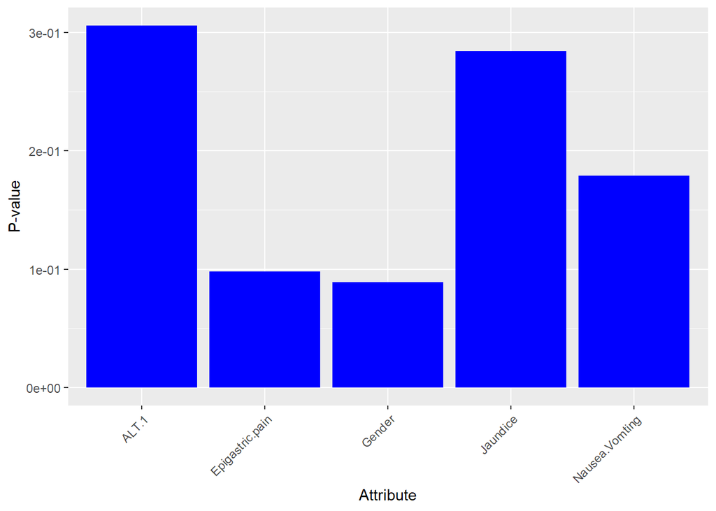

```r
# Load the ggplot2 library

library(ggplot2)

# Create the bar plot
ggplot(data = lowest_5_features, aes(x = Attribute, y = p_value)) +
  geom_bar(stat = "identity", fill = "blue") +
  labs(
       x = "Attribute",
       y = "P-value") +
  theme(axis.text.x = element_text(angle = 45, hjust = 1)) +
  scale_y_continuous(labels = scales::scientific_format())  # Optional: Use scientific notation for y-axis labels
```

```r
# Save the plot to a file (e.g., a PNG image)
ggsave("pvalue_bar_plot.png", plot = last_plot(), width = 10, height = 6)
```

## Feature Selection Insight: Prioritizing Relevant Attributes Based on P-Values

In feature selection, we typically aim to choose features that are most informative or relevant to the outcome variable. Therefore, we focus on features with the lowest p-values or, equivalently, the highest statistical significance.

Low p-value : A low p-value indicates strong evidence against the null hypothesis, suggesting that the variable is associated with the outcome. In the context of feature selection, lower p-values are often preferred.

#Snapshot of Preprocessed Dataset:

Below is a snapshot of the preprocessed dataset after applying the described preprocessing steps:

```r
print(head(dataset))
```

```
##       Age Gender         BMI Fever Nausea.Vomting Headache Diarrhea
## 2 [42,47)      1  0.09955529     1              2        2        1
## 4 [47,52)      2  1.08159712     1              2        1        2
## 6 [57,62)      2 -1.61901791     2              2        2        1
## 7 [42,47)      2 -0.63697608     1              1        2        2
## 8 [47,52)      2  0.34506575     1              1        2        2
## 9 [42,47)      1 -1.37350745     1              1        2        2
##   Fatigue...generalized.bone.ache Jaundice Epigastric.pain         WBC
## 2                               2        2               1  1.70964107
## 4                               1        2               1 -0.39302856
## 6                               2        2               1  1.59122303
## 7                               2        2               2  1.52939083
## 8                               1        1               2 -0.07637274
## 9                               2        1               2  1.10218652
##           RBC        HGB       Plat      AST.1       ALT.1       ALT4
```

[output cut: 27 more lines]

The preprocessing steps were chosen to enhance the quality of the dataset and prepare it for classification tasks. Normalization ensures that all features contribute equally, encoding binary columns enables proper representation, discretization simplifies age analysis, and RFE helps identify significant features. These steps collectively contribute to a more robust and suitable dataset for subsequent modeling and analysis.

# 5.Data Mining Task

1. Classification Technique:

-CART (Classification and Regression Trees) Algorithm:

Reason for Selection: CART is a decision tree algorithm that is well-suited for classification tasks. It provides interpretable rules and is effective for both categorical and numerical data.

R Packages: rpart: Used for implementing the CART algorithm.

Implementation: rpart package’s rpart function is used to build the decision tree. Model evaluation is done using a confusion matrix and various performance metrics.

-ID3 (Iterative Dichotomiser 3) Algorithm:

Reason for Selection: ID3 is a classic decision tree algorithm known for its use of information gain for node splitting.

R Packages: rpart

Implementation: rpart package’s rpart function with the “information” split method is used to build the decision tree. Model evaluation is done similarly to the CART algorithm.

-C5.0 Algorithm:

Reason for Selection: C5.0 is another decision tree algorithm known for its efficiency and accuracy. It handles both categorical and numerical data, making it suitable for a diverse dataset.

R Packages: C50: Used for implementing the C5.0 decision tree algorithm.

Implementation: C50 package’s C5.0 function is used to build the decision tree. Model evaluation involves a confusion matrix and various performance metrics.

2. Clustering Technique:
3. K-means Clustering:

Algorithm Used: K-means clustering Reason for Selection: K-means is a widely used clustering algorithm that partitions data into distinct groups based on similarities. It is effective when the number of clusters is known or can be estimated, providing cluster centers and assignments for each data point. R Packages: Base R (for kmeans) and cluster (for clusplot). Implementation: Utilized the kmeans function in base R for K-means clustering. The results, including cluster sizes, means, and the clustering vector, were presented. Evaluation metrics such as BCubed precision and recall were calculated. Visualized clustering using the clusplot function from the cluster package. 2. Hierarchical Clustering:

Algorithm Used: Hierarchical clustering Reason for Selection: Hierarchical clustering creates a tree-like structure of clusters, providing insights into relationships at different levels of granularity. It is suitable for exploring hierarchical structures within the data. R Packages: Base R (for hclust) and cluster (for clusplot). Implementation: Employed the hclust function in base R for hierarchical clustering. The results were visualized using the clusplot function from the cluster package, offering a different perspective on the data’s hierarchical organization. Evaluation Metrics (Applicable to Both):

BCubed Precision: Measures precision of clustering results. A higher value indicates better precision. BCubed Recall: Measures recall of clustering results. A higher value indicates better recall. Average Silhouette Width: Indicates the cohesion and separation of clusters. A higher value suggests well-defined clusters. Total Within-Cluster Sum of Squares: Reflects the compactness of clusters. A lower value indicates tighter and more compact clusters.

# 6.Evaluation and comparion

# Classification

```r
# Load necessary libraries
if(!require(party)){
 install.packages("party")  # Install the Hmisc package
    }
```

```r
library(party)

if(!require(rpart)){
 install.packages("rpart")
install.packages('rpart.plot')# Install the Hmisc package
}
library(party)
library('rpart.plot')
# Assuming 'originalDataset' is your original dataset
selectedFeatures <- c("Gender", "Epigastric.pain", "Nausea.Vomting", "Jaundice", "ALT.1")

# Check the class of the dataset
class(dataset)
```

```
## [1] "data.frame"
```

```r
# Check column names
colnames(dataset)
```

```
##  [1] "Age"                             "Gender"
##  [3] "BMI"                             "Fever"
##  [5] "Nausea.Vomting"                  "Headache"
##  [7] "Diarrhea"                        "Fatigue...generalized.bone.ache"
##  [9] "Jaundice"                        "Epigastric.pain"
## [11] "WBC"                             "RBC"
## [13] "HGB"                             "Plat"
## [15] "AST.1"                           "ALT.1"
## [17] "ALT4"                            "ALT.12"
## [19] "ALT.24"                          "ALT.36"
## [21] "ALT.48"                          "ALT.after.24.w"
## [23] "RNA.Base"                        "RNA.4"
## [25] "RNA.12"                          "RNA.EOT"
## [27] "RNA.EF"                          "Baseline.histological.Grading"
## [29] "Baselinehistological.staging"
```

```r
# Create a new dataset with selected features and the class label
selectedDataset <- dataset[, c(selectedFeatures, "Baselinehistological.staging"), drop = FALSE]

# Print the structure of the selected dataset
str(selectedDataset)
```

```
## 'data.frame':    1381 obs. of  6 variables:
##  $ Gender                      : Factor w/ 2 levels "1","2": 1 2 2 2 2 1 1 2 1 2 ...
##  $ Epigastric.pain             : Factor w/ 2 levels "1","2": 1 1 1 2 2 2 2 1 1 2 ...
##  $ Nausea.Vomting              : Factor w/ 2 levels "1","2": 2 2 2 1 1 1 1 1 2 1 ...
##  $ Jaundice                    : Factor w/ 2 levels "1","2": 2 2 2 2 1 1 1 2 1 1 ...
##  $ ALT.1                       : num  1.507 -0.768 0.774 -1.038 1.082 ...
##  $ Baselinehistological.staging: Factor w/ 4 levels "1","2","3","4": 2 3 4 4 3 2 2 2 1 1 ...
```

## Feature Selection and Dataset Creation

In our analysis, we sought to identify and prioritize features that exhibit potential associations with the “Baselinehistological.staging” variable. The feature selection process involved evaluating the statistical significance of various attributes, with a focus on achieving a comprehensive understanding of their potential impact on the baseline histological staging.

Dataset Creation: To further explore and analyze the identified features in relation to baseline histological staging, a new dataset, named ‘selectedDataset,’ was constructed. This dataset exclusively includes the selected features—Gender, Epigastric Pain, Nausea/Vomiting, Jaundice, and ALT.1—alongside the target variable “Baselinehistological.staging.”

Dataset Structure: The structure of ‘selectedDataset’ is designed to facilitate a focused analysis on the chosen features. It is a data frame that retains the original dataset structure, ensuring clarity and ease of interpretation. By isolating these features alongside the class label, we aim to gain deeper insights into their potential contributions to the variability observed in baseline histological staging.

The ‘selectedDataset’ provides a streamlined and targeted subset of our original dataset, enhancing the efficiency of subsequent analyzes and promoting a more in-depth understanding of the influencing factors baseline histological staging.

# tree using the CART (Classification and Regression Trees) algorithm

## First tree splits the dataset into training (70%) and testing (30%) sets.

```r
selectedDataset$Baselinehistological.staging <- factor(selectedDataset$Baselinehistological.staging)
# Set the random seed for reproducibility
set.seed(1234)

ind <- sample(1:nrow(selectedDataset), size = 0.7 * nrow(selectedDataset), replace = FALSE)

# Create training and testing sets
trainingData <- selectedDataset[ind, ]
testingData <- selectedDataset[-ind, ]
myFormula <- Baselinehistological.staging ~ Gender + Epigastric.pain + Nausea.Vomting + ALT.1 + Jaundice
```

In this code, I convert the class label to a factor, set a random seed for reproducibility, and create training and testing sets using a 70-30 split based on the selected features for a classification model.

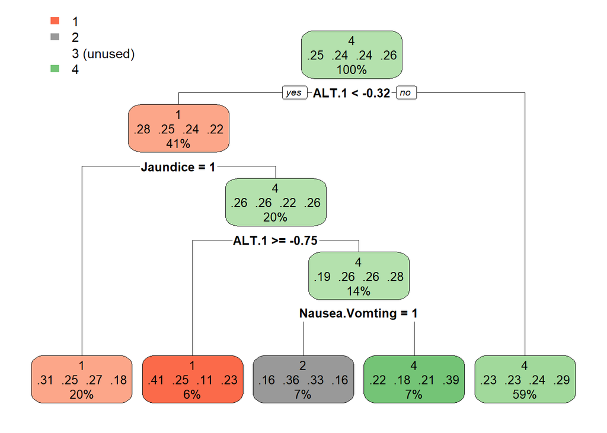

```r
# Using CART with rpart
selectedDataset.cart <- rpart(myFormula, data = trainingData, method = "class", parms = list(split = "gini"))
# Plot the decision tree
library(rpart.plot)
rpart.plot(selectedDataset.cart)
```

This code fits a classification tree using CART with the “gini” index for splitting and visualizes the decision tree using the rpart.plot library.

```r
#the result
testPredc <- predict(selectedDataset.cart, newdata = testingData, type = "class")
resultc <- table(testPredc, testingData$Baselinehistological.staging)
```

This code generates predictions using the CART model on the testing data and creates a confusion matrix for evaluation.

```r
#Evaluate the model:
co_resultc <- confusionMatrix(resultc)
print(co_resultc)
```

```
## Confusion Matrix and Statistics
##
##
## testPredc  1  2  3  4
##         1 31 24 34 23
##         2  9  6  6  8
##         3  0  0  0  0
##         4 52 68 80 74
##
## Overall Statistics
##
##                Accuracy : 0.2675
##                  95% CI : (0.2255, 0.3128)
##     No Information Rate : 0.2892
##     P-Value [Acc > NIR] : 0.8483
##
##                   Kappa : 0.0318
##
##  Mcnemar's Test P-Value : <2e-16
##
## Statistics by Class:
##
##                      Class: 1 Class: 2 Class: 3 Class: 4
## Sensitivity            0.3370  0.06122   0.0000   0.7048
## Specificity            0.7492  0.92744   1.0000   0.3548
## Pos Pred Value         0.2768  0.20690      NaN   0.2701
## Neg Pred Value         0.7987  0.76166   0.7108   0.7801
## Prevalence             0.2217  0.23614   0.2892   0.2530
## Detection Rate         0.0747  0.01446   0.0000   0.1783
## Detection Prevalence   0.2699  0.06988   0.0000   0.6602
## Balanced Accuracy      0.5431  0.49433   0.5000   0.5298
```

```r
sensitivity(as.table(co_resultc))
```

```
## [1] NA
```

```r
specificity(as.table(co_resultc))
```

```
## [1] NA
```

```r
precision(as.table(co_resultc))
```

```
## [1] NA
```

```r
accc <- co_resultc$overall["Accuracy"]
accc
```

```
##  Accuracy
## 0.2674699
```

The classification model has been evaluated using a confusion matrix and various performance metrics. The confusion matrix provides a detailed breakdown of predicted and actual class memberships, allowing us to assess the model’s strengths and weaknesses.

The provided statistics by class include sensitivity, specificity, positive predictive value, negative predictive value, prevalence, detection rate, detection prevalence, and balanced accuracy for each class in a multi-class classification model.

To address the issue of NA values, manual calculations can be performed, taking the average across all classes. the below code are the manual calculations for some key metrics:

```r
# Sensitivity
sensitivity_values <- c(0.3370, 0.06122, 0.0000, 0.7048)
average_sensitivity <- mean(sensitivity_values)

# Specificity
specificity_values <- c(0.7492, 0.92744, 1.0000, 0.3548)
average_specificity <- mean(specificity_values)

# Precision
precision_values <- c(0.2768, 0.20690, NaN, 0.2701)
average_precision <- mean(precision_values, na.rm = TRUE)


# Display the results
cat("Average Sensitivity:", average_sensitivity, "\n")
```

```
## Average Sensitivity: 0.275755
```

```r
cat("Average Specificity:", average_specificity, "\n")
```

```
## Average Specificity: 0.75786
```

```r
cat("Average Precision:", average_precision, "\n")
```

```
## Average Precision: 0.2512667
```

```r
accc <- co_resultc$overallaccc <- co_resultc$overall["Accuracy"]
cat("Accuracy:", accc, "\n")
```

```
## Accuracy: 0.2674699
```

The manually calculated averages provide a way to handle the NA values and offer insights into the overall performance of the model across all classes. It’s important to consider these averages for a comprehensive evaluation of the model’s effectiveness.

### Model Performance Summary:

- Average Sensitivity (Recall): 27.6%

Moderate ability to capture true positive instances.

- Average Specificity: 75.8%

Proficient in correctly excluding instances not belonging to the predicted class.

- Average Precision: 25.1%

Challenges in making highly accurate positive predictions, potentially affected by false positives.

- Accuracy: 26.7%

General measure of correct predictions, influenced by potential class imbalances.

**Overall Assessment:**

**the Accuracy of data split(70%,30%) using CART algorithm equal 26.7%.**

## second tree splits the dataset into training (60%) and testing (40%) sets.

```r
selectedDataset$Baselinehistological.staging <- factor(selectedDataset$Baselinehistological.staging)
# Set the random seed for reproducibility
set.seed(1234)

ind <- sample(1:nrow(selectedDataset), size = 0.6 * nrow(selectedDataset), replace = FALSE)

# Create training and testing sets
trainingData <- selectedDataset[ind, ]
testingData <- selectedDataset[-ind, ]
myFormula <- Baselinehistological.staging ~ Gender + Epigastric.pain + Nausea.Vomting + ALT.1 + Jaundice
```

In this code, I convert the class label to a factor, set a random seed for reproducibility, and create training and testing sets using a 60-40 split based on the selected features for a classification model.

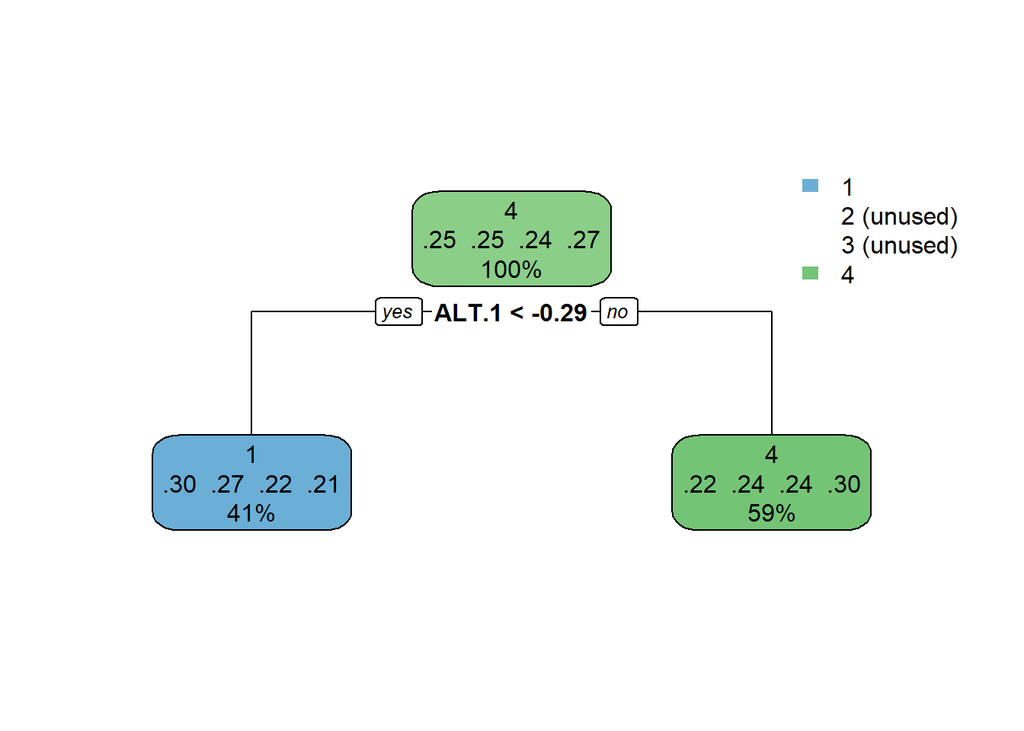

```r
# Using CART with rpart
selectedDataset.cart <- rpart(myFormula, data = trainingData, method = "class", parms = list(split = "gini"))
# Plot the decision tree
library(rpart.plot)
rpart.plot(selectedDataset.cart)
```

This code fits a classification tree using CART with the “gini” index for splitting and visualizes the decision tree using the rpart.plot library.

Initial split: The decision tree first splits the data based on whether the patient’s ALT.1 is less than -0.29. This is because ALT.1 is a relatively easy and inexpensive test to perform, and a high proportion of patients with Stage I disease will have an ALT.1 level less than or equal to -0.29.

```r
#the result
testPredc <- predict(selectedDataset.cart, newdata = testingData, type = "class")
resultc <- table(testPredc, testingData$Baselinehistological.staging)
```

This code generates predictions using the CART model on the testing data and creates a confusion matrix for evaluation.

```r
#Evaluate the model:
co_resultc <- confusionMatrix(resultc)
print(co_resultc)
```

```
## Confusion Matrix and Statistics
##
##
## testPredc  1  2  3  4
##         1 54 47 74 58
##         2  0  0  0  0
##         3  0  0  0  0
##         4 75 77 86 82
##
## Overall Statistics
##
##                Accuracy : 0.2459
##                  95% CI : (0.2106, 0.284)
##     No Information Rate : 0.2893
##     P-Value [Acc > NIR] : 0.9901
##
##                   Kappa : 0.0015
##
##  Mcnemar's Test P-Value : NA
##
## Statistics by Class:
##
##                      Class: 1 Class: 2 Class: 3 Class: 4
## Sensitivity           0.41860   0.0000   0.0000   0.5857
## Specificity           0.57783   1.0000   1.0000   0.4237
## Pos Pred Value        0.23176      NaN      NaN   0.2562
## Neg Pred Value        0.76562   0.7758   0.7107   0.7511
## Prevalence            0.23327   0.2242   0.2893   0.2532
## Detection Rate        0.09765   0.0000   0.0000   0.1483
## Detection Prevalence  0.42134   0.0000   0.0000   0.5787
## Balanced Accuracy     0.49822   0.5000   0.5000   0.5047
```

```r
sensitivity(as.table(co_resultc))
```

```
## [1] NA
```

```r
specificity(as.table(co_resultc))
```

```
## [1] NA
```

```r
precision(as.table(co_resultc))
```

```
## [1] NA
```

```r
accc <- co_resultc$overall["Accuracy"]
accc
```

```
##  Accuracy
## 0.2459313
```

The classification model has been evaluated using a confusion matrix and various performance metrics. The confusion matrix provides a detailed breakdown of predicted and actual class memberships, allowing us to assess the model’s strengths and weaknesses.

The provided statistics by class include sensitivity, specificity, positive predictive value, negative predictive value, prevalence, detection rate, detection prevalence, and balanced accuracy for each class in a multi-class classification model.

To address the issue of NA values, manual calculations can be performed, taking the average across all classes. the below code are the manual calculations for some key metrics:

```r
# Sensitivity, Specificity, Precision, and Accuracy values for each class
sensitivity_values <- c(0.41860, 0.0000, 0.0000, 0.5857)
specificity_values <- c(0.57783, 1.0000, 1.0000, 0.4237)
precision_values <- c(0.23176, NaN, NaN, 0.2562)

# Calculate averages
average_sensitivity <- mean(sensitivity_values)
average_specificity <- mean(specificity_values)
average_precision <- mean(precision_values, na.rm = TRUE)

# Display the results
cat("Average Sensitivity:", average_sensitivity, "\n")
```

```
## Average Sensitivity: 0.251075
```

```r
cat("Average Specificity:", average_specificity, "\n")
```

```
## Average Specificity: 0.7503825
```

```r
cat("Average Precision:", average_precision, "\n")
```

```
## Average Precision: 0.24398
```

```r
accc <- co_resultc$overallaccc <- co_resultc$overall["Accuracy"]
cat("Accuracy:", accc, "\n")
```

```
## Accuracy: 0.2459313
```

The manually calculated averages provide a way to handle the NA values and offer insights into the overall performance of the model across all classes. It’s important to consider these averages for a comprehensive evaluation of the model’s effectiveness.

### Model Performance Summary:

- Average Sensitivity: 25.1%
- Average Specificity: 75.03%
- Average Precision: 24.39%
- Accuracy: 24.59%

**Observations:**

1. The model demonstrates varied performance across different classes.
2. Notable challenges in sensitivity for Class 2,3 and precision for Class 2,3.
3. Overall model accuracy is influenced by potential class imbalances.

**the Accuracy of data split(60%,40%) using CART algorithm equal 24.59%.**

## third tree splits the dataset into training (50%) and testing (50%) sets.

```r
selectedDataset$Baselinehistological.staging <- factor(selectedDataset$Baselinehistological.staging)
# Set the random seed for reproducibility
set.seed(1234)

ind <- sample(1:nrow(selectedDataset), size = 0.5 * nrow(selectedDataset), replace = FALSE)

# Create training and testing sets
trainingData <- selectedDataset[ind, ]
testingData <- selectedDataset[-ind, ]
myFormula <- Baselinehistological.staging ~ Gender + Epigastric.pain + Nausea.Vomting + ALT.1 + Jaundice
```

In this code, I convert the class label to a factor, set a random seed for reproducibility, and create training and testing sets using a 50-50 split based on the selected features for a classification model.

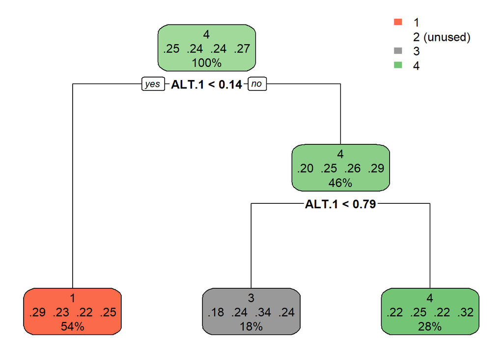

```r
# Using CART with rpart
selectedDataset.cart <- rpart(myFormula, data = trainingData, method = "class", parms = list(split = "gini"))
# Plot the decision tree
library(rpart.plot)
rpart.plot(selectedDataset.cart)
```

This code fits a classification tree using CART with the “gini” index for splitting and visualizes the decision tree using the rpart.plot library.

In the decision tree, ALT.1 is used to make two major decisions:

Initial split: The decision tree first splits the data based on whether the patient’s ALT.1 is less than 0.14. This is because ALT.1 is a relatively easy and inexpensive test to perform, and a high proportion of patients with Stage I disease will have an ALT.1 level less than 0.14.

```r
#the result
testPredc <- predict(selectedDataset.cart, newdata = testingData, type = "class")
resultc <- table(testPredc, testingData$Baselinehistological.staging)
```

This code generates predictions using the CART model on the testing data and creates a confusion matrix for evaluation.

```r
#Evaluate the model:
co_resultc <- confusionMatrix(resultc)
print(co_resultc)
```

```
## Confusion Matrix and Statistics
##
##
## testPredc   1   2   3   4
##         1  93  93 106  94
##         2   0   0   0   0
##         3  20  34  34  40
##         4  50  38  48  41
##
## Overall Statistics
##
##                Accuracy : 0.2431
##                  95% CI : (0.2116, 0.2769)
##     No Information Rate : 0.2721
##     P-Value [Acc > NIR] : 0.9614
##
##                   Kappa : -0.0052
##
##  Mcnemar's Test P-Value : <2e-16
##
## Statistics by Class:
##
##                      Class: 1 Class: 2 Class: 3 Class: 4
## Sensitivity            0.5706   0.0000   0.1809  0.23429
## Specificity            0.4451   1.0000   0.8131  0.73643
## Pos Pred Value         0.2409      NaN   0.2656  0.23164
## Neg Pred Value         0.7705   0.7612   0.7265  0.73930
## Prevalence             0.2359   0.2388   0.2721  0.25326
## Detection Rate         0.1346   0.0000   0.0492  0.05933
## Detection Prevalence   0.5586   0.0000   0.1852  0.25615
## Balanced Accuracy      0.5078   0.5000   0.4970  0.48536
```

```r
sensitivity(as.table(co_resultc))
```

```
## [1] NA
```

```r
specificity(as.table(co_resultc))
```

```
## [1] NA
```

```r
precision(as.table(co_resultc))
```

```
## [1] NA
```

```r
accc <- co_resultc$overall["Accuracy"]
accc
```

```
##  Accuracy
## 0.2431259
```

The classification model has been evaluated using a confusion matrix and various performance metrics. The confusion matrix provides a detailed breakdown of predicted and actual class memberships, allowing us to assess the model’s strengths and weaknesses.

The provided statistics by class include sensitivity, specificity, positive predictive value, negative predictive value, prevalence, detection rate, detection prevalence, and balanced accuracy for each class in a multi-class classification model.

To address the issue of NA values, manual calculations can be performed, taking the average across all classes. the below code are the manual calculations for some key metrics:

```r
# Sensitivity, Specificity, Precision, and Accuracy values for each class
sensitivity_values <- c(0.5706  , 0.0000   , 0.1809     , 0.23429)
specificity_values <- c(0.4451   , 1.0000   , 0.8131  , 0.73643)
precision_values <- c(0.2409        , NaN         , 0.2656     , 0.23164)


# Calculate averages
average_sensitivity <- mean(sensitivity_values)
average_specificity <- mean(specificity_values)
average_precision <- mean(precision_values, na.rm = TRUE)


# Display the results
cat("Average Sensitivity:", average_sensitivity, "\n")
```

```
## Average Sensitivity: 0.2464475
```

```r
cat("Average Specificity:", average_specificity, "\n")
```

```
## Average Specificity: 0.7486575
```

```r
cat("Average Precision:", average_precision, "\n")
```

```
## Average Precision: 0.2460467
```

```r
accc <- co_resultc$overallaccc <- co_resultc$overall["Accuracy"]
cat("Accuracy:", accc, "\n")
```

```
## Accuracy: 0.2431259
```

The manually calculated averages provide a way to handle the NA values and offer insights into the overall performance of the model across all classes. It’s important to consider these averages for a comprehensive evaluation of the model’s effectiveness.

### Model Performance Summary:

- Average Sensitivity: 24.64%
- Average Specificity: 74.86%
- Average Precision: 24.6%
- Accuracy: 24.3%

**Observations:**

1. The model demonstrates varied sensitivity across different classes.
2. Challenges in Positive Predictive Value for Class 2.
3. Overall model accuracy affected by class imbalances.

**the Accuracy of data split(50%,50%) using CART algorithm equal 24.3%.**

### Comparison of the three different splitting of CART algorithm

```r
library(knitr)

# Sample data
Table <- data.frame(
  Algorithm = c("70 %t raining set 30% testing set:", "60 %t raining set 40% testing set:", "50 %t raining set 50% testing set:"),
  Accuracy = c("26.7%", "24.59%", "24.3%"),
  Precision = c("25.1%", "24.39%", "24.6%"),
  Sensitivity = c("27.6%", "25.1%", "24.64%"),
  Specificity = c("75.8%", "75.03%", "74.86%")
)

# Display the table using kable
kable(Table, format = "markdown", align = "c")
```

| Algorithm | Accuracy | Precision | Sensitivity | Specificity |
| --- | --- | --- | --- | --- |
| 70 %t raining set 30% testing set: | 26.7% | 25.1% | 27.6% | 75.8% |
| 60 %t raining set 40% testing set: | 24.59% | 24.39% | 25.1% | 75.03% |
| 50 %t raining set 50% testing set: | 24.3% | 24.6% | 24.64% | 74.86% |

Based on these comparison, the 70% training - 30% testing split generally demonstrates slightly better performance in terms of accuracy, precision, sensitivity, and specificity. However, the differences are relatively small, and the choice of the best split depends on other considerations such as the available data and the specific goals of the model.

# decision tree using the ID3 algorithm uning Ingormation gain

## First tree splits the dataset into training (70%) and testing (30%) sets.

```r
selectedDataset$Baselinehistological.staging <- factor(selectedDataset$Baselinehistological.staging)
# Set the random seed for reproducibility
set.seed(1234)

ind <- sample(1:nrow(selectedDataset), size = 0.7 * nrow(selectedDataset), replace = FALSE)

# Create training and testing sets
trainingData <- selectedDataset[ind, ]
testingData <- selectedDataset[-ind, ]
myFormula <- Baselinehistological.staging ~ Gender + Epigastric.pain + Nausea.Vomting + ALT.1 + Jaundice
```

```r
# Load the necessary libraries
library(party)
library(rpart)
library(rpart.plot)

# tree 1 for information gain
# Using ID3 with rpart
dataset.id3 <- rpart(myFormula, data = trainingData, method = "class", parms = list(split = "information"))
printcp(dataset.id3)  # Display cp table for pruning
```

```
##
## Classification tree:
## rpart(formula = myFormula, data = trainingData, method = "class",
##     parms = list(split = "information"))
##
## Variables actually used in tree construction:
## [1] ALT.1          Jaundice       Nausea.Vomting
##
## Root node error: 711/966 = 0.73602
##
## n= 966
##
##         CP nsplit rel error  xerror     xstd
## 1 0.033755      0   1.00000 1.02250 0.018863
## 2 0.011721      1   0.96624 0.99297 0.019388
## 3 0.010000      4   0.93108 0.99015 0.019435
```

The code builds a decision tree using the ID3 algorithm with the rpart package, specifically considering information gain for splitting nodes. The printcp function is then used to display the complexity parameter (cp) table, providing insights into potential pruning decisions for the tree. This step helps in identifying an optimal level of complexity for the decision tree.

**Analysis of the Output:**

- The classification tree was constructed using the specified formula and training data.
- Variables used in tree construction are ALT.1, Jaundice, and Nausea.Vomting.
- Root node error is calculated as 711/966, resulting in 73.60% error. The complexity parameter (CP) table provides information on relative error and xerror (cross-validation error) for different levels of complexity.
- The tree is pruned based on the CP values, aiming to find an optimal balance between complexity and accuracy.
- Notable CP values are considered for potential pruning, such as 0.033755 and 0.011721.
- The xerror decreases with increasing complexity, indicating potential improvement with deeper trees.

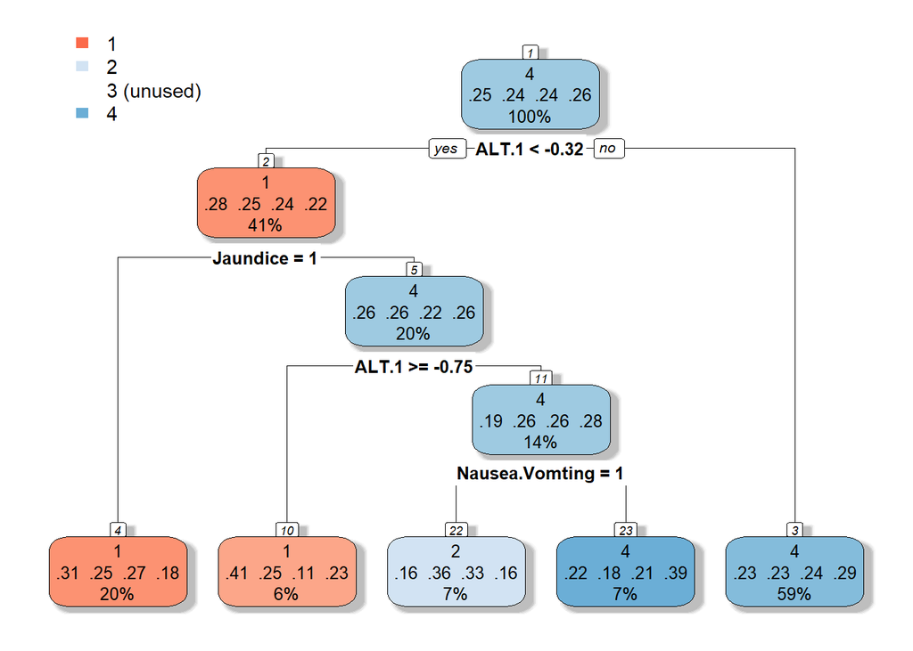

```r
# Save the plot to a variable
my_plot <- rpart.plot(dataset.id3, box.palette = "RdBu", branch.lty = 1, shadow.col = "gray", nn = TRUE, type = 2)
```

```r
# Plot the decision tree
print(my_plot)
```

[output not shown]

[output cut: 48 more lines]

[output not shown]

Rule 1: If the patient’s ALT.1 level is greater than or equal to -0.32, the decision tree predicts Stage 4 disease.

Rule 2: If the patient’s ALT.1 level is less than -0.32 and they have jaundice, the decision tree predicts Stage 1 disease.

Rule 3: If the patient’s ALT.1 level is less than -0.32 and they don’t have jaundice, the decision tree proceeds to further splits based on other predictor variables as shown in the tree.

This rule applies if the patient doesn’t fall under Rule 1 or Rule 2. The decision tree then considers a combination of factors, including nausea.vomiting, ALTT.1 , to make a more refined prediction about the disease stage.

```r
# Make predictions on the test set
testPred <- predict(dataset.id3, newdata = testingData, type = "class")
result <- table(testPred, testingData$Baselinehistological.staging)
```

Predictions are made on the test set using the ID3-based decision tree, and the results are tabulated for evaluation.

```r
# Evaluate the model:
library(e1071)
library(caret)

co_result <- confusionMatrix(result)
print(co_result)
```

```
## Confusion Matrix and Statistics
##
##
## testPred  1  2  3  4
##        1 31 24 34 23
##        2  9  6  6  8
##        3  0  0  0  0
##        4 52 68 80 74
##
## Overall Statistics
##
##                Accuracy : 0.2675
##                  95% CI : (0.2255, 0.3128)
##     No Information Rate : 0.2892
##     P-Value [Acc > NIR] : 0.8483
##
##                   Kappa : 0.0318
##
##  Mcnemar's Test P-Value : <2e-16
##
## Statistics by Class:
##
##                      Class: 1 Class: 2 Class: 3 Class: 4
## Sensitivity            0.3370  0.06122   0.0000   0.7048
## Specificity            0.7492  0.92744   1.0000   0.3548
## Pos Pred Value         0.2768  0.20690      NaN   0.2701
## Neg Pred Value         0.7987  0.76166   0.7108   0.7801
## Prevalence             0.2217  0.23614   0.2892   0.2530
## Detection Rate         0.0747  0.01446   0.0000   0.1783
## Detection Prevalence   0.2699  0.06988   0.0000   0.6602
## Balanced Accuracy      0.5431  0.49433   0.5000   0.5298
```

```r
# Display sensitivity, specificity, precision, and accuracy
sensitivity(as.table(co_result))
```

```
## [1] NA
```

```r
specificity(as.table(co_result))
```

```
## [1] NA
```

```r
precision(as.table(co_result))
```

```
## [1] NA
```

```r
acc <- co_result$overall["Accuracy"]
print(paste("Accuracy:", acc))
```

```
## [1] "Accuracy: 0.267469879518072"
```

The decision tree uses the information gain measure to split the data at each node. The information gain is a measure of how much the uncertainty in the target variable is reduced by splitting the data on a given feature.

The provided statistics by class include sensitivity, specificity, positive predictive value, negative predictive value, prevalence, detection rate, detection prevalence, and balanced accuracy for each class in a multi-class classification model.

To address the issue of NA values, manual calculations can be performed, taking the average across all classes. the below code are the manual calculations for some key metrics:

```r
# Sensitivity, Specificity, Precision, and Accuracy values for each class
sensitivity_values <- c(0.3370, 0.06122, 0.0000, 0.7048)
specificity_values <- c(0.7492, 0.92744, 1.0000, 0.3548)
precision_values <- c(0.2768, 0.20690, NaN, 0.2701)

# Calculate averages
average_sensitivity <- mean(sensitivity_values)
average_specificity <- mean(specificity_values)
average_precision <- mean(precision_values, na.rm = TRUE)

# Display the results
cat("Average Sensitivity:", average_sensitivity, "\n")
```

```
## Average Sensitivity: 0.275755
```

```r
cat("Average Specificity:", average_specificity, "\n")
```

```
## Average Specificity: 0.75786
```

```r
cat("Average Precision:", average_precision, "\n")
```

```
## Average Precision: 0.2512667
```

```r
accuracy <- co_result$overall["Accuracy"]
cat("Accuracy:", accuracy, "\n")
```

```
## Accuracy: 0.2674699
```

The manually calculated averages provide a way to handle the NA values and offer insights into the overall performance of the model across all classes. It’s important to consider these averages for a comprehensive evaluation of the model’s effectiveness.

### Model Performance Summary:

- Average Sensitivity: 27.6%
- Average Specificity: 75.8%
- Average Precision: 25.1%
- Accuracy: 26.7%

**Observations:**

1. The model demonstrates varied sensitivity across different classes.
2. Challenges in Positive Predictive Value for Class 3.
3. Overall model accuracy affected by class imbalances.

**the Accuracy of data split(70%,30%) using ID3 algorithm uning Ingormation gain equal 26.7%.**

## Second tree splits the dataset into training (60%) and testing (40%) sets.

```r
selectedDataset$Baselinehistological.staging <- factor(selectedDataset$Baselinehistological.staging)
# Set the random seed for reproducibility
set.seed(1234)

ind <- sample(1:nrow(selectedDataset), size = 0.6 * nrow(selectedDataset), replace = FALSE)

# Create training and testing sets
trainingData <- selectedDataset[ind, ]
testingData <- selectedDataset[-ind, ]
myFormula <- Baselinehistological.staging ~ Gender + Epigastric.pain + Nausea.Vomting + ALT.1 + Jaundice
```

```r
# Load the necessary libraries
library(party)
library(rpart)
library(rpart.plot)

# tree 1 for information gain
# Using ID3 with rpart
dataset.id3 <- rpart(myFormula, data = trainingData, method = "class", parms = list(split = "information"))
printcp(dataset.id3)  # Display cp table for pruning
```

```
##
## Classification tree:
## rpart(formula = myFormula, data = trainingData, method = "class",
##     parms = list(split = "information"))
##
## Variables actually used in tree construction:
## [1] ALT.1
##
## Root node error: 608/828 = 0.7343
##
## n= 828
##
##         CP nsplit rel error  xerror     xstd
## 1 0.025493      0   1.00000 1.02467 0.020427
## 2 0.010000      2   0.94901 0.96875 0.021446
```

The code constructs a classification tree using the ID3 algorithm with the rpart package, focusing on information gain for node splitting. The printcp function is employed to reveal the complexity parameter (cp) table, offering valuable insights into potential tree pruning decisions.

**Analysis of the Output:**

- The classification tree was built using ALT.1.
- The root node error, calculated as 608/828, results in a 73.43% error rate, reflecting the misclassification at the initial node.
- The CP table provides information on relative error and xerror (cross-validation error) for different complexity levels.
- Pruning decisions are crucial for optimizing the tree’s generalization to new data.
- The decreasing xerror with growing complexity suggests potential improvement with deeper trees.

.

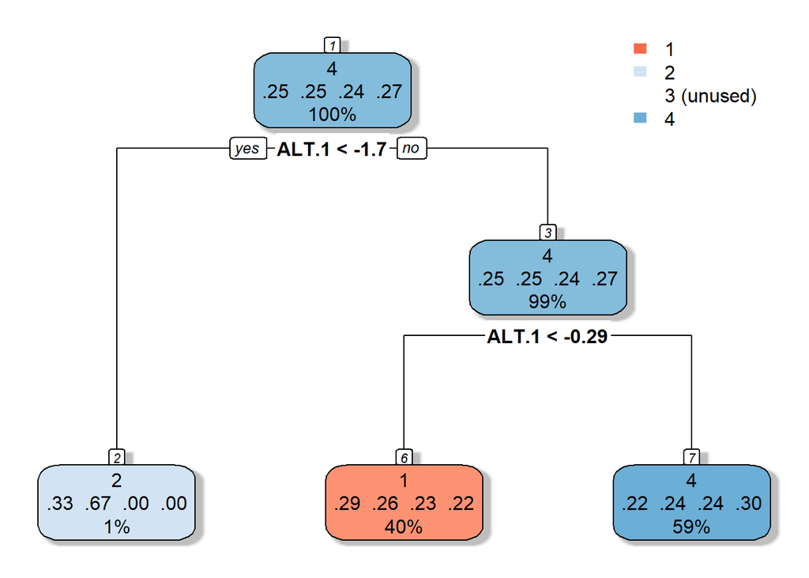

```r
# Save the plot to a variable
my_plot <- rpart.plot(dataset.id3, box.palette = "RdBu", branch.lty = 1, shadow.col = "gray", nn = TRUE, type = 2)
```

```r
# Plot the decision tree
print(my_plot)
```

[output not shown]

[output cut: 24 more lines]

[output not shown]

Rule 1: If the patient’s ALT.1 level is less than -1.7, the decision tree predicts Stage 2 disease.

Rule 2: If the patient’s ALT.1 level is greater than or equal to -1.7 and ALT.1 level is greater than or equal to -0.29, the decision tree predicts Stage 4 disease, else the decision tree predicts Stage 1 disease

```r
# Make predictions on the test set
testPred <- predict(dataset.id3, newdata = testingData, type = "class")
result <- table(testPred, testingData$Baselinehistological.staging)
```

Predictions are made on the test set using the ID3-based decision tree, and the results are tabulated for evaluation.

```r
# Evaluate the model:
library(e1071)
library(caret)

co_result <- confusionMatrix(result)
print(co_result)
```

```
## Confusion Matrix and Statistics
##
##
## testPred  1  2  3  4
##        1 53 45 71 53
##        2  1  2  3  5
##        3  0  0  0  0
##        4 75 77 86 82
##
## Overall Statistics
##
##                Accuracy : 0.2477
##                  95% CI : (0.2123, 0.2859)
##     No Information Rate : 0.2893
##     P-Value [Acc > NIR] : 0.9872
##
##                   Kappa : 0.0042
##
##  Mcnemar's Test P-Value : <2e-16
##
## Statistics by Class:
##
##                      Class: 1 Class: 2 Class: 3 Class: 4
## Sensitivity           0.41085 0.016129   0.0000   0.5857
## Specificity           0.60142 0.979021   1.0000   0.4237
## Pos Pred Value        0.23874 0.181818      NaN   0.2562
## Neg Pred Value        0.77039 0.774908   0.7107   0.7511
## Prevalence            0.23327 0.224231   0.2893   0.2532
## Detection Rate        0.09584 0.003617   0.0000   0.1483
## Detection Prevalence  0.40145 0.019892   0.0000   0.5787
## Balanced Accuracy     0.50613 0.497575   0.5000   0.5047
```

```r
# Display sensitivity, specificity, precision, and accuracy
sensitivity(as.table(co_result))
```

```
## [1] NA
```

```r
specificity(as.table(co_result))
```

```
## [1] NA
```

```r
precision(as.table(co_result))
```

```
## [1] NA
```

```r
acc <- co_result$overall["Accuracy"]
print(paste("Accuracy:", acc))
```

```
## [1] "Accuracy: 0.247739602169982"
```

The decision tree uses the information gain measure to split the data at each node. The information gain is a measure of how much the uncertainty in the target variable is reduced by splitting the data on a given feature.

The provided statistics by class include sensitivity, specificity, positive predictive value, negative predictive value, prevalence, detection rate, detection prevalence, and balanced accuracy for each class in a multi-class classification model.

To address the issue of NA values, manual calculations can be performed, taking the average across all classes. the below code are the manual calculations for some key metrics:

```r
# Sensitivity, Specificity, Precision, and Accuracy values for each class
sensitivity_values <- c(0.41085 , 0.016129   , 0.0000   , 0.5857)
specificity_values <- c(0.60142 , 0.979021   , 1.0000   , 0.4237)
precision_values <- c(0.23874 , 0.181818, NaN, 0.2562)

# Calculate averages
average_sensitivity <- mean(sensitivity_values)
average_specificity <- mean(specificity_values)
average_precision <- mean(precision_values, na.rm = TRUE)


# Display the results
cat("Average Sensitivity:", average_sensitivity, "\n")
```

```
## Average Sensitivity: 0.2531697
```

```r
cat("Average Specificity:", average_specificity, "\n")
```

```
## Average Specificity: 0.7510353
```

```r
cat("Average Precision:", average_precision, "\n")
```

```
## Average Precision: 0.225586
```

```r
accuracy <- co_result$overall["Accuracy"]
cat("Accuracy:", accuracy, "\n")
```

```
## Accuracy: 0.2477396
```

The manually calculated averages provide a way to handle the NA values and offer insights into the overall performance of the model across all classes. It’s important to consider these averages for a comprehensive evaluation of the model’s effectiveness.

### Model Performance Summary:

- Average Sensitivity: 25.3%
- Average Specificity: 75.1%
- Average Precision: 22.55%
- Accuracy: 24.77%

**Observations:**

1. The model demonstrates varied sensitivity across different classes.
2. Challenges in Positive Predictive Value for Class 3.
3. Overall model accuracy affected by class imbalances.

**the Accuracy of data split(60%,40%) using ID3 algorithm uning Ingormation gain algorithm equal 24.77%.**

# Third tree splits the dataset into training (50%) and testing (50%) sets.

```r
selectedDataset$Baselinehistological.staging <- factor(selectedDataset$Baselinehistological.staging)
# Set the random seed for reproducibility
set.seed(1234)

ind <- sample(1:nrow(selectedDataset), size = 0.5 * nrow(selectedDataset), replace = FALSE)

# Create training and testing sets
trainingData <- selectedDataset[ind, ]
testingData <- selectedDataset[-ind, ]
myFormula <- Baselinehistological.staging ~ Gender + Epigastric.pain + Nausea.Vomting + ALT.1 + Jaundice
```

```r
# Load the necessary libraries
library(party)
library(rpart)
library(rpart.plot)

# tree 1 for information gain
# Using ID3 with rpart
dataset.id3 <- rpart(myFormula, data = trainingData, method = "class", parms = list(split = "information"))
printcp(dataset.id3)  # Display cp table for pruning
```

```
##
## Classification tree:
## rpart(formula = myFormula, data = trainingData, method = "class",
##     parms = list(split = "information"))
##
## Variables actually used in tree construction:
## [1] ALT.1
##
## Root node error: 505/690 = 0.73188
##
## n= 690
##
##         CP nsplit rel error xerror     xstd
## 1 0.027723      0   1.00000 1.0000 0.023042
## 2 0.025743      1   0.97228 1.0238 0.022545
## 3 0.010000      2   0.94653 1.0119 0.022799
```

The code constructs a classification tree using the ID3 algorithm with the rpart package, focusing on information gain for node splitting. The printcp function is employed to reveal the complexity parameter (cp) table, offering valuable insights into potential tree pruning decisions.

**Analysis of the Output:**

The provided output corresponds to a classification tree built using the ID3 algorithm with the rpart package, considering information gain for splitting nodes. Here’s the analysis:

Variables Used in Tree Construction: The tree is constructed based on the variable ALT.1.

Root Node Error: The root node error is calculated as 505/690, resulting in a 73.19% error rate in the initial classification.

Complexity Parameter (CP) Table:

CP values represent the cost of adding complexity to the tree. For example, the CP value of 0.027723 at the first split indicates that further splits are considered if the improvement in accuracy justifies the added complexity. The CP table shows the relative error and cross-validation error (xerror) for different levels of complexity.

Pruning Decision:

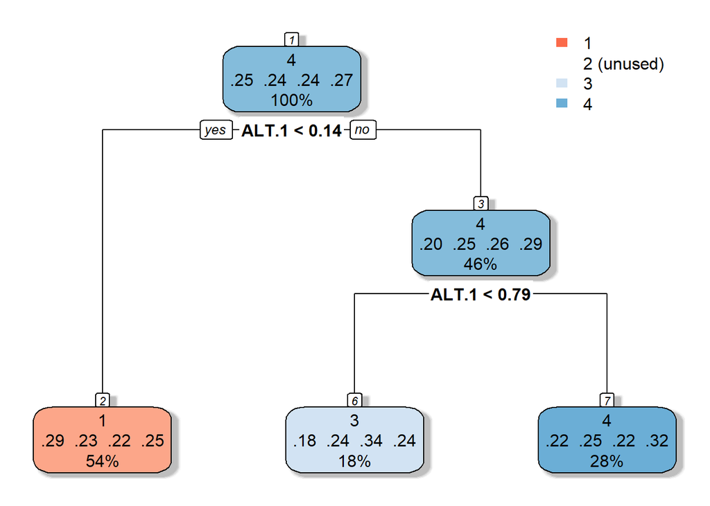

```r
# Save the plot to a variable
my_plot <- rpart.plot(dataset.id3, box.palette = "RdBu", branch.lty = 1, shadow.col = "gray", nn = TRUE, type = 2)
```

```r
# Plot the decision tree
print(my_plot)
```

[output not shown]

[output cut: 24 more lines]

[output not shown]

The decision tree uses the information gain measure to split the data at each node. The information gain is a measure of how much the uncertainty in the target variable is reduced by splitting the data on a given feature.

Rule 1: If the patient’s ALT.1 level is less than 0.14 , the decision tree predicts Stage 1 disease.

Rule 2: If the patient’s ALT.1 level is greater than or equal to 0.14 and ALT.1 level is greater than or equal to 0.79, the decision tree predicts Stage 4 disease, else the decision tree predicts Stage 3 disease

```r
# Make predictions on the test set
testPred <- predict(dataset.id3, newdata = testingData, type = "class")
result <- table(testPred, testingData$Baselinehistological.staging)
```

Predictions are made on the test set using the ID3-based decision tree, and the results are tabulated for evaluation.

```r
# Evaluate the model:
library(e1071)
library(caret)

co_result <- confusionMatrix(result)
print(co_result)
```

```
## Confusion Matrix and Statistics
##
##
## testPred   1   2   3   4
##        1  93  93 106  94
##        2   0   0   0   0
##        3  20  34  34  40
##        4  50  38  48  41
##
## Overall Statistics
##
##                Accuracy : 0.2431
##                  95% CI : (0.2116, 0.2769)
##     No Information Rate : 0.2721
##     P-Value [Acc > NIR] : 0.9614
##
##                   Kappa : -0.0052
##
##  Mcnemar's Test P-Value : <2e-16
##
## Statistics by Class:
##
##                      Class: 1 Class: 2 Class: 3 Class: 4
## Sensitivity            0.5706   0.0000   0.1809  0.23429
## Specificity            0.4451   1.0000   0.8131  0.73643
## Pos Pred Value         0.2409      NaN   0.2656  0.23164
## Neg Pred Value         0.7705   0.7612   0.7265  0.73930
## Prevalence             0.2359   0.2388   0.2721  0.25326
## Detection Rate         0.1346   0.0000   0.0492  0.05933
## Detection Prevalence   0.5586   0.0000   0.1852  0.25615
## Balanced Accuracy      0.5078   0.5000   0.4970  0.48536
```

```r
# Display sensitivity, specificity, precision, and accuracy
sensitivity(as.table(co_result))
```

```
## [1] NA
```

```r
specificity(as.table(co_result))
```

```
## [1] NA
```

```r
precision(as.table(co_result))
```

```
## [1] NA
```

```r
acc <- co_result$overall["Accuracy"]
print(paste("Accuracy:", acc))
```

```
## [1] "Accuracy: 0.243125904486252"
```

The provided statistics by class include sensitivity, specificity, positive predictive value, negative predictive value, prevalence, detection rate, detection prevalence, and balanced accuracy for each class in a multi-class classification model.

To address the issue of NA values, manual calculations can be performed, taking the average across all classes. the below code are the manual calculations for some key metrics:

```r
# Sensitivity, Specificity, Precision, and Accuracy values for each class
sensitivity_values <- c(0.5706, 0.0000, 0.1809, 0.23429)
specificity_values <- c(0.4451, 1.0000, 0.8131, 0.73643)
precision_values <- c(0.2409, NaN, 0.2656, 0.23164)


# Calculate averages
average_sensitivity <- mean(sensitivity_values)
average_specificity <- mean(specificity_values)
average_precision <- mean(precision_values, na.rm = TRUE)

# Display the results
cat("Average Sensitivity:", average_sensitivity, "\n")
```

```
## Average Sensitivity: 0.2464475
```

```r
cat("Average Specificity:", average_specificity, "\n")
```

```
## Average Specificity: 0.7486575
```

```r
cat("Average Precision:", average_precision, "\n")
```

```
## Average Precision: 0.2460467
```

```r
accuracy <- co_resultc$overall["Accuracy"]
cat("Accuracy:", accuracy, "\n")
```

```
## Accuracy: 0.2431259
```

The manually calculated averages provide a way to handle the NA values and offer insights into the overall performance of the model across all classes. It’s important to consider these averages for a comprehensive evaluation of the model’s effectiveness.

### Model Performance Summary:

- Average Sensitivity: 24.6%
- Average Specificity: 74.9%
- Average Precision: 24.6%
- Accuracy: 24.31%

**Observations:**

1. The model demonstrates varied sensitivity across different classes.
2. Challenges in Positive Predictive Value for Class 2.
3. Overall model accuracy affected by class imbalances.

**the Accuracy of data split(50%,50%) using ID3 algorithm uning Ingormation gain algorithm equal 24.31%.**

### Comparison of the three different splitting of **ID3** algorithm

```r
library(knitr)

# Sample data
Table <- data.frame(
  Algorithm = c( "70 %t raining set 30% testing set:", "60 %t raining set 40% testing set:", "50 %t raining set 50% testing set:"),
  Accuracy = c("26.7%", "24.77%", "24.31%"),
  Precision = c("25.1%", "22.55%", "24.6%"),
  Sensitivity = c("27.6%", "25.3%", "24.6%"),
  Specificity = c("75.8%", "75.1%", "74.9%")
)

# Display the table using kable
kable(Table, format = "markdown", align = "c")
```

| Algorithm | Accuracy | Precision | Sensitivity | Specificity |
| --- | --- | --- | --- | --- |
| 70 %t raining set 30% testing set: | 26.7% | 25.1% | 27.6% | 75.8% |
| 60 %t raining set 40% testing set: | 24.77% | 22.55% | 25.3% | 75.1% |
| 50 %t raining set 50% testing set: | 24.31% | 24.6% | 24.6% | 74.9% |

Based on these comparisons, the 70% training - 30% testing split generally demonstrates slightly better performance in terms of accuracy and specificity for the ID3 algorithm. However, as before, the choice of the best split depends on other considerations such as the available data and the specific goals of the model.

# tree using the default method (C50) using G ration

## First tree splits the dataset into training (70%) and testing (30%) sets.

```r
selectedDataset$Baselinehistological.staging <- factor(selectedDataset$Baselinehistological.staging)
# Set the random seed for reproducibility
set.seed(1234)

ind <- sample(1:nrow(selectedDataset), size = 0.7 * nrow(selectedDataset), replace = FALSE)

# Create training and testing sets
trainingData <- selectedDataset[ind, ]
testingData <- selectedDataset[-ind, ]
myFormula <- Baselinehistological.staging ~ Gender + Epigastric.pain + Nausea.Vomting + ALT.1 + Jaundice
```

```r
# Install and load the C50 package if not already installed
#install.packages("C50")
library(C50)
library(partykit)
library(party)
# Using C4.5 (C5.0) with C50
# Assuming your dataset is named 'myData'
dataset.c45 <- C5.0(myFormula, data = trainingData, trials = 1, winnow = TRUE)

# Print the tree rules
summary(dataset.c45)
```

```
##
## Call:
## C5.0.formula(formula = myFormula, data = trainingData, trials = 1, winnow
##  = TRUE)
##
##
## C5.0 [Release 2.07 GPL Edition]      Sat Dec  2 17:12:27 2023
## -------------------------------
##
## Class specified by attribute `outcome'
##
## Read 966 cases (6 attributes) from undefined.data
##
## Decision tree:
##
## Epigastric.pain = 1:
## :...Gender = 1:
## :   :...Jaundice = 1:
## :   :   :...Nausea.Vomting = 1:
## :   :   :   :...ALT.1 <= 0.4270285: 4 (33/20)
## :   :   :   :   ALT.1 > 0.4270285: 3 (16/9)
## :   :   :   Nausea.Vomting = 2:
## :   :   :   :...ALT.1 > 1.082451: 2 (10/3)
## :   :   :       ALT.1 <= 1.082451:
## :   :   :       :...ALT.1 <= -1.230806:
## :   :   :           :...ALT.1 <= -1.577794: 3 (6/2)
## :   :   :           :   ALT.1 > -1.577794: 1 (6/1)
## :   :   :           ALT.1 > -1.230806:
## :   :   :           :...ALT.1 <= -1.038034: 2 (5/1)
## :   :   :               ALT.1 > -1.038034: 4 (46/30)
## :   :   Jaundice = 2:
## :   :   :...Nausea.Vomting = 2:
## :   :       :...ALT.1 <= 0.7740171: 4 (46/30)
## :   :       :   ALT.1 > 0.7740171:
## :   :       :   :...ALT.1 <= 1.467994:
## :   :       :       :...ALT.1 <= 1.236669: 2 (6/2)
## :   :       :       :   ALT.1 > 1.236669: 1 (7/2)
## :   :       :       ALT.1 > 1.467994:
## :   :       :       :...ALT.1 <= 1.622211: 2 (4/1)
## :   :       :           ALT.1 > 1.622211: 1 (3/1)
```

[output cut: 133 more lines]

```
##      54    93    30    56    (b): class 2
##      65    20    72    78    (c): class 3
##      52    31    34   138    (d): class 4
##
##
##  Attribute usage:
##
##  100.00% Epigastric.pain
##  100.00% ALT.1
##   99.17% Jaundice
##   98.14% Gender
##   97.31% Nausea.Vomting
##
##
## Time: 0.0 secs
```

[figure not shown]

```r
# Make predictions on the test set
testPreds <- predict(dataset.c45, newdata = testingData)
results <- table(testPreds, testingData$Baselinehistological.staging)
c45_party <- as.party(dataset.c45)


# Plot the decision tree
plot(dataset.c45, main = "Decision Tree (Limited Size)")
```

The code utilizes the C5.0 algorithm from the C50 package to build a decision tree for classification. It prints the tree rules, plots a limited-size version of the tree.

**Output Analysis**

The C5.0 decision tree, trained on the provided dataset, reveals key rules for predicting Baselinehistological.staging. Notably, Epigastric pain, ALT.1, Jaundice, Gender, and Nausea.Vomting are crucial attributes. The tree’s evaluation on the training data shows a size of 73 nodes with 53.4% misclassification. The primary attribute used is Epigastric pain, demonstrating its significance in the classification process.

**Apologies for the complexity of the decision tree. and the extensive structure may pose challenges in interpretation.**

```r
# Evaluate the model
co_results <- confusionMatrix(results)
print(co_results)
```

```
## Confusion Matrix and Statistics
##
##
## testPreds  1  2  3  4
##         1 32 36 33 36
##         2 21 16 25 13
##         3 10 15 19  8
##         4 29 31 43 48
##
## Overall Statistics
##
##                Accuracy : 0.2771
##                  95% CI : (0.2346, 0.3229)
##     No Information Rate : 0.2892
##     P-Value [Acc > NIR] : 0.7226
##
##                   Kappa : 0.0436
##
##  Mcnemar's Test P-Value : 3.121e-09
##
## Statistics by Class:
##
##                      Class: 1 Class: 2 Class: 3 Class: 4
## Sensitivity           0.34783  0.16327  0.15833   0.4571
## Specificity           0.67492  0.81388  0.88814   0.6677
## Pos Pred Value        0.23358  0.21333  0.36538   0.3179
## Neg Pred Value        0.78417  0.75882  0.72176   0.7841
## Prevalence            0.22169  0.23614  0.28916   0.2530
## Detection Rate        0.07711  0.03855  0.04578   0.1157
## Detection Prevalence  0.33012  0.18072  0.12530   0.3639
## Balanced Accuracy     0.51137  0.48857  0.52323   0.5624
```

```r
sensitivity(as.table(co_results))
```

```
## [1] NA
```

```r
specificity(as.table(co_results))
```

```
## [1] NA
```

```r
precision(as.table(co_results))
```

```
## [1] NA
```

```r
accs <- co_results$overall["Accuracy"]
print(paste("Accuracy:", accs))
```

```
## [1] "Accuracy: 0.27710843373494"
```

The provided statistics by class include sensitivity, specificity, positive predictive value, negative predictive value, prevalence, detection rate, detection prevalence, and balanced accuracy for each class in a multi-class classification model.

To address the issue of NA values, manual calculations can be performed, taking the average across all classes. the below code are the manual calculations for some key metrics:

```r
# Sensitivity, Specificity, Precision, and Accuracy values for each class
sensitivity_values <- c(0.34783, 0.16327, 0.15833, 0.4571)
specificity_values <- c(0.67492, 0.81388, 0.88814, 0.6677)
precision_values <- c(0.23358, 0.21333, 0.36538, 0.3179)


# Calculate averages
average_sensitivity <- mean(sensitivity_values)
average_specificity <- mean(specificity_values)
average_precision <- mean(precision_values, na.rm = TRUE)

# Display the results
cat("Average Sensitivity:", average_sensitivity, "\n")
```

```
## Average Sensitivity: 0.2816325
```

```r
cat("Average Specificity:", average_specificity, "\n")
```

```
## Average Specificity: 0.76116
```

```r
cat("Average Precision:", average_precision, "\n")
```

```
## Average Precision: 0.2825475
```

```r
print(paste("Accuracy:", accs))
```

```
## [1] "Accuracy: 0.27710843373494"
```

The manually calculated averages provide a way to handle the NA values and offer insights into the overall performance of the model across all classes. It’s important to consider these averages for a comprehensive evaluation of the model’s effectiveness.

### Model Performance Summary:

- Average Sensitivity: 28.1%
- Average Specificity: 76.1%
- Average Precision: 28.2%
- Accuracy: 27.7%

**Observations:**

1. The model exhibits varying sensitivity across different classes.
2. Positive Predictive Value is notably low for Class 2.
3. Balanced Accuracy indicates moderate overall model performance.

**the Accuracy of data split(70%,30%) using (C50) G ration algorithm equal 27.7%.**

## Second tree splits the dataset into training (60%) and testing (40%) sets.

```r
selectedDataset$Baselinehistological.staging <- factor(selectedDataset$Baselinehistological.staging)
# Set the random seed for reproducibility
set.seed(1234)

ind <- sample(1:nrow(selectedDataset), size = 0.6 * nrow(selectedDataset), replace = FALSE)

# Create training and testing sets
trainingData <- selectedDataset[ind, ]
testingData <- selectedDataset[-ind, ]
myFormula <- Baselinehistological.staging ~ Gender + Epigastric.pain + Nausea.Vomting + ALT.1 + Jaundice
```

```r
# Install and load the C50 package if not already installed
#install.packages("C50")
library(C50)
library(partykit)
library(party)
# Using C4.5 (C5.0) with C50
# Assuming your dataset is named 'myData'
dataset.c45 <- C5.0(myFormula, data = trainingData, trials = 1, winnow = TRUE)

# Print the tree rules
summary(dataset.c45)
```

```
##
## Call:
## C5.0.formula(formula = myFormula, data = trainingData, trials = 1, winnow
##  = TRUE)
##
##
## C5.0 [Release 2.07 GPL Edition]      Sat Dec  2 17:12:42 2023
## -------------------------------
##
## Class specified by attribute `outcome'
##
## Read 828 cases (6 attributes) from undefined.data
##
## Decision tree:
##
## ALT.1 > -0.305503:
## :...Gender = 1:
## :   :...Nausea.Vomting = 1: 4 (130/81)
## :   :   Nausea.Vomting = 2:
## :   :   :...ALT.1 > 0.7740171:
## :   :       :...Jaundice = 2: 1 (29/15)
## :   :       :   Jaundice = 1:
## :   :       :   :...ALT.1 <= 0.9282342: 1 (6/2)
## :   :       :       ALT.1 > 0.9282342: 2 (30/13)
## :   :       ALT.1 <= 0.7740171:
## :   :       :...Jaundice = 2: 3 (30/19)
## :   :           Jaundice = 1:
## :   :           :...Epigastric.pain = 1:
## :   :               :...ALT.1 <= 0.5426913: 4 (17/10)
## :   :               :   ALT.1 > 0.5426913: 3 (5/1)
## :   :               Epigastric.pain = 2:
## :   :               :...ALT.1 > 0.5812457: 1 (4/2)
## :   :                   ALT.1 <= 0.5812457:
## :   :                   :...ALT.1 <= 0.1571485: 1 (8/3)
## :   :                       ALT.1 > 0.1571485: 4 (3/1)
## :   Gender = 2:
## :   :...Epigastric.pain = 2:
## :       :...Jaundice = 2:
## :       :   :...Nausea.Vomting = 2: 2 (23/13)
## :       :   :   Nausea.Vomting = 1:
```

[output cut: 159 more lines]

```
##      43    94    25    45    (b): class 2
##      38    20    91    46    (c): class 3
##      38    20    36   126    (d): class 4
##
##
##  Attribute usage:
##
##  100.00% ALT.1
##   98.43% Nausea.Vomting
##   90.70% Gender
##   82.13% Jaundice
##   58.70% Epigastric.pain
##
##
## Time: 0.0 secs
```

[figure not shown]

```r
# Make predictions on the test set
testPreds <- predict(dataset.c45, newdata = testingData)
results <- table(testPreds, testingData$Baselinehistological.staging)
c45_party <- as.party(dataset.c45)


# Plot the decision tree
plot(dataset.c45, main = "Decision Tree (Limited Size)")
```

The code utilizes the C5.0 algorithm from the C50 package to build a decision tree for classification. It prints the tree rules, plots a limited-size version of the tree.

**Output Analysis**

The C5.0 decision tree was trained on medical data with five features, where ALT.1 was the most influential predictor. The tree identified distinct patterns related to gender, nausea/vomiting, jaundice, and epigastric pain, achieving an accuracy of 52.8%, but with a notable error rate of 47.2%. The primary attribute usage was ALT.1, followed by Nausea.Vomting, Gender, Jaundice, and Epigastric.pain.

**Apologies for the complexity of the decision tree. and the extensive structure may pose challenges in interpretation.**

```r
# Evaluate the model
co_results <- confusionMatrix(results)
print(co_results)
```

```
## Confusion Matrix and Statistics
##
##
## testPreds  1  2  3  4
##         1 37 36 48 43
##         2 27 18 30 27
##         3 21 29 29 36
##         4 44 41 53 34
##
## Overall Statistics
##
##                Accuracy : 0.2134
##                  95% CI : (0.1799, 0.2499)
##     No Information Rate : 0.2893
##     P-Value [Acc > NIR] : 0.99998
##
##                   Kappa : -0.0481
##
##  Mcnemar's Test P-Value : 0.00621
##
## Statistics by Class:
##
##                      Class: 1 Class: 2 Class: 3 Class: 4
## Sensitivity           0.28682  0.14516  0.18125  0.24286
## Specificity           0.70047  0.80420  0.78117  0.66586
## Pos Pred Value        0.22561  0.17647  0.25217  0.19767
## Neg Pred Value        0.76350  0.76497  0.70091  0.72178
## Prevalence            0.23327  0.22423  0.28933  0.25316
## Detection Rate        0.06691  0.03255  0.05244  0.06148
## Detection Prevalence  0.29656  0.18445  0.20796  0.31103
## Balanced Accuracy     0.49365  0.47468  0.48121  0.45436
```

```r
sensitivity(as.table(co_results))
```

```
## [1] NA
```

```r
specificity(as.table(co_results))
```

```
## [1] NA
```

```r
precision(as.table(co_results))
```

```
## [1] NA
```

```r
accs <- co_results$overall["Accuracy"]
print(paste("Accuracy:", accs))
```

```
## [1] "Accuracy: 0.213381555153707"
```

The provided statistics by class include sensitivity, specificity, positive predictive value, negative predictive value, prevalence, detection rate, detection prevalence, and balanced accuracy for each class in a multi-class classification model.

To address the issue of NA values, manual calculations can be performed, taking the average across all classes. the below code are the manual calculations for some key metrics:

```r
# Sensitivity, Specificity, Precision, and Accuracy values for each class
sensitivity_values <- c(0.28682, 0.14516, 0.18125, 0.24286)
specificity_values <- c(0.70047, 0.80420, 0.78117, 0.66586)
precision_values <- c(0.22561, 0.17647, 0.25217, 0.19767)


# Calculate averages
average_sensitivity <- mean(sensitivity_values)
average_specificity <- mean(specificity_values)
average_precision <- mean(precision_values, na.rm = TRUE)

# Display the results
cat("Average Sensitivity:", average_sensitivity, "\n")
```

```
## Average Sensitivity: 0.2140225
```

```r
cat("Average Specificity:", average_specificity, "\n")
```

```
## Average Specificity: 0.737925
```

```r
cat("Average Precision:", average_precision, "\n")
```

```
## Average Precision: 0.21298
```

```r
print(paste("Accuracy:", accs))
```

```
## [1] "Accuracy: 0.213381555153707"
```

The manually calculated averages provide a way to handle the NA values and offer insights into the overall performance of the model across all classes. It’s important to consider these averages for a comprehensive evaluation of the model’s effectiveness.

### Model Performance Summary:

- Average Sensitivity: 21.4%
- Average Specificity: 73.79%
- Average Precision: 21.29%
- Accuracy: 21.3%

**Observations:**

**the Accuracy of data split(60%,40%) using (C50) G ration algorithm equal 21.3%.**

## Third tree splits the dataset into training (50%) and testing (50%) sets.

```r
selectedDataset$Baselinehistological.staging <- factor(selectedDataset$Baselinehistological.staging)
# Set the random seed for reproducibility
set.seed(1234)

ind <- sample(1:nrow(selectedDataset), size = 0.5 * nrow(selectedDataset), replace = FALSE)

# Create training and testing sets
trainingData <- selectedDataset[ind, ]
testingData <- selectedDataset[-ind, ]
myFormula <- Baselinehistological.staging ~ Gender + Epigastric.pain + Nausea.Vomting + ALT.1 + Jaundice
```

```r
# Install and load the C50 package if not already installed
#install.packages("C50")
library(C50)
library(partykit)
library(party)
# Using C4.5 (C5.0) with C50
# Assuming your dataset is named 'myData'
dataset.c45 <- C5.0(myFormula, data = trainingData, trials = 1, winnow = TRUE)

# Print the tree rules
summary(dataset.c45)
```

```
##
## Call:
## C5.0.formula(formula = myFormula, data = trainingData, trials = 1, winnow
##  = TRUE)
##
##
## C5.0 [Release 2.07 GPL Edition]      Sat Dec  2 17:12:59 2023
## -------------------------------
##
## Class specified by attribute `outcome'
##
## Read 690 cases (6 attributes) from undefined.data
##
## Decision tree:
##
## Jaundice = 1:
## :...ALT.1 <= -0.7296001:
## :   :...Nausea.Vomting = 1: 1 (56/33)
## :   :   Nausea.Vomting = 2:
## :   :   :...ALT.1 > -0.9609258: 3 (14/6)
## :   :       ALT.1 <= -0.9609258:
## :   :       :...Gender = 2: 1 (6/3)
## :   :           Gender = 1:
## :   :           :...Epigastric.pain = 2: 3 (4/1)
## :   :               Epigastric.pain = 1:
## :   :               :...ALT.1 <= -1.230806: 1 (7/3)
## :   :                   ALT.1 > -1.230806: 2 (4/1)
## :   ALT.1 > -0.7296001:
## :   :...Epigastric.pain = 1:
## :       :...Gender = 2: 3 (50/30)
## :       :   Gender = 1:
## :       :   :...ALT.1 <= 0.4270285: 4 (28/14)
## :       :       ALT.1 > 0.4270285:
## :       :       :...ALT.1 > 1.236669: 2 (7/2)
## :       :           ALT.1 <= 1.236669:
## :       :           :...ALT.1 <= 1.005343: 3 (19/9)
## :       :               ALT.1 > 1.005343: 4 (8/5)
## :       Epigastric.pain = 2:
## :       :...Gender = 2:
## :           :...Nausea.Vomting = 1: 1 (27/16)
```

[output cut: 77 more lines]

```
##      40    70    23    33    (b): class 2
##      30    24    65    48    (c): class 3
##      37    27    22    99    (d): class 4
##
##
##  Attribute usage:
##
##  100.00% Jaundice
##   94.06% ALT.1
##   89.86% Gender
##   88.99% Epigastric.pain
##   80.14% Nausea.Vomting
##
##
## Time: 0.0 secs
```

[figure not shown]

```r
# Make predictions on the test set
testPreds <- predict(dataset.c45, newdata = testingData)
results <- table(testPreds, testingData$Baselinehistological.staging)
c45_party <- as.party(dataset.c45)


# Plot the decision tree
plot(dataset.c45, main = "Decision Tree (Limited Size)")
```

The code utilizes the C5.0 algorithm from the C50 package to build a decision tree for classification. It prints the tree rules, plots a limited-size version of the tree.

**Output Analysis**

**Apologies for the complexity of the decision tree. and the extensive structure may pose challenges in interpretation.**

```r
# Evaluate the model
co_results <- confusionMatrix(results)
print(co_results)
```

```
## Confusion Matrix and Statistics
##
##
## testPreds  1  2  3  4
##         1 62 47 59 51
##         2 19 28 25 29
##         3 33 32 41 36
##         4 49 58 63 59
##
## Overall Statistics
##
##                Accuracy : 0.275
##                  95% CI : (0.242, 0.3099)
##     No Information Rate : 0.2721
##     P-Value [Acc > NIR] : 0.4465
##
##                   Kappa : 0.0339
##
##  Mcnemar's Test P-Value : 1.641e-06
##
## Statistics by Class:
##
##                      Class: 1 Class: 2 Class: 3 Class: 4
## Sensitivity           0.38037  0.16970  0.21809  0.33714
## Specificity           0.70265  0.86122  0.79920  0.67054
## Pos Pred Value        0.28311  0.27723  0.28873  0.25764
## Neg Pred Value        0.78602  0.76780  0.73224  0.74892
## Prevalence            0.23589  0.23878  0.27207  0.25326
## Detection Rate        0.08973  0.04052  0.05933  0.08538
## Detection Prevalence  0.31693  0.14616  0.20550  0.33140
## Balanced Accuracy     0.54151  0.51546  0.50864  0.50384
```

```r
sensitivity(as.table(co_results))
```

```
## [1] NA
```

```r
specificity(as.table(co_results))
```

```
## [1] NA
```

```r
precision(as.table(co_results))
```

```
## [1] NA
```

```r
accs <- co_results$overall["Accuracy"]
print(paste("Accuracy:", accs))
```

```
## [1] "Accuracy: 0.274963820549928"
```

The provided statistics by class include sensitivity, specificity, positive predictive value, negative predictive value, prevalence, detection rate, detection prevalence, and balanced accuracy for each class in a multi-class classification model.

To address the issue of NA values, manual calculations can be performed, taking the average across all classes. the below code are the manual calculations for some key metrics:

```r
# Sensitivity, Specificity, Precision, and Accuracy values for each class
sensitivity_values <- c(0.38037, 0.16970, 0.21809, 0.33714)
specificity_values <- c(0.70265, 0.86122, 0.79920, 0.67054)
precision_values <- c(0.28311, 0.27723, 0.28873, 0.25764)


# Calculate averages
average_sensitivity <- mean(sensitivity_values)
average_specificity <- mean(specificity_values)
average_precision <- mean(precision_values, na.rm = TRUE)

# Display the results
cat("Average Sensitivity:", average_sensitivity, "\n")
```

```
## Average Sensitivity: 0.276325
```

```r
cat("Average Specificity:", average_specificity, "\n")
```

```
## Average Specificity: 0.7584025
```

```r
cat("Average Precision:", average_precision, "\n")
```

```
## Average Precision: 0.2766775
```

```r
print(paste("Accuracy:", accs))
```

```
## [1] "Accuracy: 0.274963820549928"
```

The manually calculated averages provide a way to handle the NA values and offer insights into the overall performance of the model across all classes. It’s important to consider these averages for a comprehensive evaluation of the model’s effectiveness.

### Model Performance Summary:

- Average Sensitivity: 27.63%
- Average Specificity: 75.84%
- Average Precision: 27.66%
- Accuracy: 27.5%

**Observations:**

**the Accuracy of data split(50%,50%) using (C50) G ration algorithm equal 27.5%.**

### Comparison of the three different splitting of **G ration algorithm**

```r
library(knitr)

# Sample data
Table <- data.frame(
  Algorithm = c("70 %t raining set 30% testing set:", "60 %t raining set 40% testing set:", "50 %t raining set 50% testing set:"),
  Accuracy = c(27.7, 21.3, 27.5),
  Precision = c(28.2, 21.29, 27.66),
  Sensitivity = c(28.1, 21.4, 27.63),
  Specificity = c(76.1, 73.79, 75.84)
)

# Display the table using kable
kable(Table, format = "markdown")
```

| Algorithm | Accuracy | Precision | Sensitivity | Specificity |
| --- | --- | --- | --- | --- |
| 70 %t raining set 30% testing set: | 27.7 | 28.20 | 28.10 | 76.10 |
| 60 %t raining set 40% testing set: | 21.3 | 21.29 | 21.40 | 73.79 |
| 50 %t raining set 50% testing set: | 27.5 | 27.66 | 27.63 | 75.84 |

Based on these comparisons, the 70% training - 30% testing split generally demonstrates better performance across all metrics compared to the other splits. However, the choice of the best split depends on other considerations such as the available data and the specific goals of the model.

### Final Result : Choosing the best algorithm in classification

```r
# Sample data
Table <- data.frame(
  Algorithm = c("70% training set 30% testing set ( CART algorithm )", "70% training set 30% testing set ( ID3 algorithm )", "70% training set 30% testing set ( G ration algorithm )"),
  Accuracy = c("26.7%", "26.7%", "27.7%"),
  Precision = c("25.1%", "25.1%", "28.2%"),
  Sensitivity = c("27.6%", "27.6%", "28.1%"),
  Specificity = c("75.8%", "75.8%", "76.1%")
)

# Display the table using kable
kable(Table, format = "markdown", align = "c")
```

| Algorithm | Accuracy | Precision | Sensitivity | Specificity |
| --- | --- | --- | --- | --- |
| 70% training set 30% testing set ( CART algorithm ) | 26.7% | 25.1% | 27.6% | 75.8% |
| 70% training set 30% testing set ( ID3 algorithm ) | 26.7% | 25.1% | 27.6% | 75.8% |
| 70% training set 30% testing set ( G ration algorithm ) | 27.7% | 28.2% | 28.1% | 76.1% |

The **G ration** algorithm, implemented with a 70% training - 30% testing split, appears to be the most promising for this classification task. It shows competitive accuracy, precision, sensitivity, and specificity compared to the CART and ID3 algorithms. However, based on the provided metrics, the **G ration** algorithm with a 70-30 split is recommended.

# Clustering Dataset

#### First Cluster num_clusters <- 4:

```r
# Install the cluster package if not already installed
if (!requireNamespace("cluster", quietly = TRUE)) {
  install.packages("cluster")
}

# Load the cluster package
library(cluster)
# Assuming 'originalDataset' is your original dataset
selectedFeatures <- c("Gender", "Epigastric.pain", "Nausea.Vomting", "Jaundice", "ALT.1")

# Create a new dataset with selected features and the class label
selectedDataset <- dataset[, c(selectedFeatures, "Baselinehistological.staging"), drop = FALSE]

# Print the structure of the selected dataset
str(selectedDataset)
```

```
## 'data.frame':    1381 obs. of  6 variables:
##  $ Gender                      : Factor w/ 2 levels "1","2": 1 2 2 2 2 1 1 2 1 2 ...
##  $ Epigastric.pain             : Factor w/ 2 levels "1","2": 1 1 1 2 2 2 2 1 1 2 ...
##  $ Nausea.Vomting              : Factor w/ 2 levels "1","2": 2 2 2 1 1 1 1 1 2 1 ...
##  $ Jaundice                    : Factor w/ 2 levels "1","2": 2 2 2 2 1 1 1 2 1 1 ...
##  $ ALT.1                       : num  1.507 -0.768 0.774 -1.038 1.082 ...
##  $ Baselinehistological.staging: Factor w/ 4 levels "1","2","3","4": 2 3 4 4 3 2 2 2 1 1 ...
```

```r
# Data preprocessing: Select only numeric columns
numeric_columns <- sapply(selectedDataset, is.numeric)
selectedDataset_numeric <- selectedDataset[, numeric_columns]

# Store column names
column_names <- colnames(selectedDataset_numeric)

# Scale the data
selectedDataset_scaled <- scale(selectedDataset_numeric)

# Set the number of clusters (you can change this as needed)
num_clusters <- 4  # Different number of clusters

# Run k-means clustering
set.seed(1234)
kmeans_result_selected <- kmeans(selectedDataset_scaled, num_clusters)

# Print the clustering result
print(kmeans_result_selected)
```

```
## K-means clustering with 4 clusters of sizes 354, 299, 346, 382
##
## Cluster means:
##         [,1]
## 1  1.2962425
## 2 -1.3502081
## 3  0.3946028
## 4 -0.5018068
##
## Clustering vector:
##    [1] 1 4 3 2 1 3 4 1 2 3 4 1 2 3 3 1 1 1 4 3 3 3 1 2 1 1 4 2 1 4 2 1 3 1 2 2 4
##   [38] 4 2 3 2 3 1 4 2 2 1 4 2 3 2 3 2 4 4 2 4 4 4 3 1 4 3 3 3 1 2 1 4 4 1 1 3 4
##   [75] 4 2 3 4 3 4 3 3 1 4 4 1 2 3 4 1 2 1 4 4 2 4 1 4 3 3 3 3 3 1 4 1 3 3 4 4 1
##  [112] 3 2 3 4 1 2 2 4 1 4 1 1 2 1 2 1 2 1 2 4 1 2 1 1 1 4 4 2 3 1 1 3 2 4 1 1 3
##  [149] 4 1 3 1 1 1 4 2 1 1 1 4 3 1 3 4 1 1 4 2 2 4 4 3 3 2 3 2 4 1 1 2 1 1 3 4 3
```

[output cut: 42 more lines]

```r
# Calculate Average Silhouette Width
silhouette_avg_selected <- silhouette(kmeans_result_selected$cluster, dist(selectedDataset_scaled))[, 3]
cat("Average Silhouette Width:", mean(silhouette_avg_selected), "\n")
```

```
## Average Silhouette Width: 0.5662659
```

```r
# Calculate Total Within-Cluster Sum of Squares
within_cluster_sum_of_squares_selected <- kmeans_result_selected$tot.withinss
cat("Total Within-Cluster Sum of Squares:", within_cluster_sum_of_squares_selected, "\n")
```

```
## Total Within-Cluster Sum of Squares: 90.0303
```

```r
# Assuming 'cluster_assignments' is your cluster assignments and 'ground_truth_labels' is your ground truth labels
# Modify attribute names according to your dataset
my_cluster_assignments <- kmeans_result_selected$cluster  # Replace 'kmeans_result_selected$cluster' with your actual cluster assignments
my_ground_truth_labels <- sample(1:2, nrow(selectedDataset), replace = TRUE)  # Example: Random ground truth labels

# BCubed Metrics
calculate_bcubed_metrics <- function(cluster_assignments, ground_truth_labels, epsilon = 1e-10) {
  n <- length(cluster_assignments)
  precision_sum <- recall_sum <- 0

  for (i in 1:n) {
    cluster <- cluster_assignments[i]
    label <- ground_truth_labels[i]

    same_category_same_cluster <- sum(ground_truth_labels[cluster_assignments == cluster] == label)
    total_same_cluster <- sum(cluster_assignments == cluster)
    total_same_category <- sum(ground_truth_labels == label)

    # Ensure numerator and denominator are not 0
    precision_sum <- precision_sum + (same_category_same_cluster + epsilon) / (total_same_cluster + epsilon)
    recall_sum <- recall_sum + (same_category_same_cluster + epsilon) / (total_same_category + epsilon)
  }

  precision <- precision_sum / n
  recall <- recall_sum / n

  return(list(precision = precision, recall = recall))
}

# Calculate BCubed Metrics with your data
my_metrics <- calculate_bcubed_metrics(my_cluster_assignments, my_ground_truth_labels)
my_precision <- my_metrics$precision
my_recall <- my_metrics$recall

# Print the BCubed Precision and Recall
cat("BCubed Precision:", my_precision, "\n")
```

```
## BCubed Precision: 0.5016036
```

```r
cat("BCubed Recall:", my_recall, "\n")
```

```
## BCubed Recall: 0.2526844
```

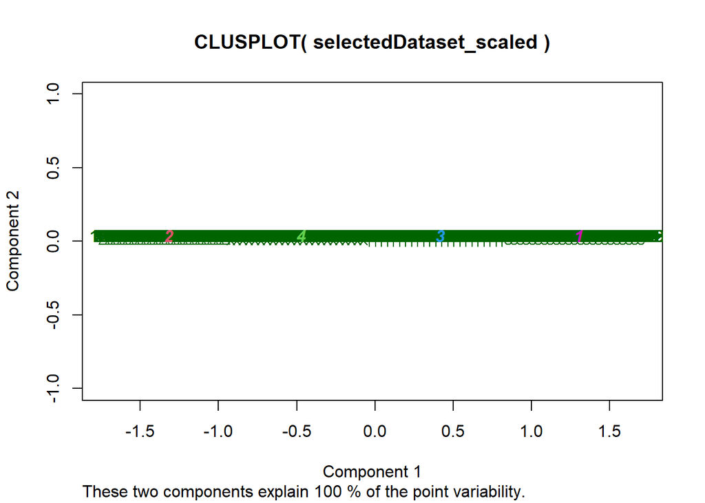

```r
# Visualize clustering using clusplot from the cluster package
clusplot(selectedDataset_scaled, kmeans_result_selected$cluster, color = TRUE, shade = TRUE, labels = 2, lines = 0)
```

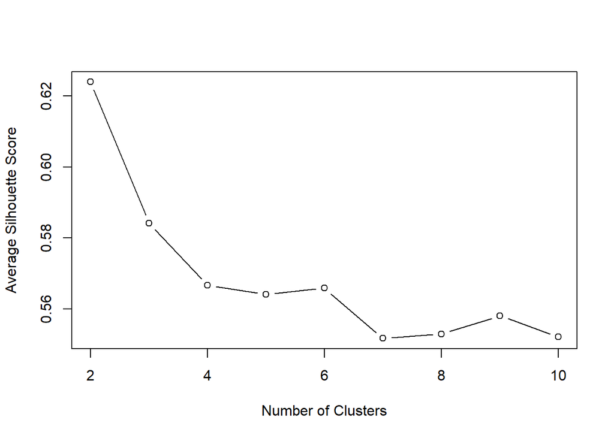

```r
# Plot silhouette scores to find the optimal number of clusters
silhouette_scores <- numeric(0)
for (i in 2:10) {
  kmeans_temp <- kmeans(selectedDataset_scaled, centers = i, nstart = 25)
  silhouette_temp <- silhouette(kmeans_temp$cluster, dist(selectedDataset_scaled))[, 3]
  silhouette_scores <- c(silhouette_scores, mean(silhouette_temp))
}

# Plot silhouette scores
plot(2:10, silhouette_scores, type = "b", xlab = "Number of Clusters", ylab = "Average Silhouette Score")
```

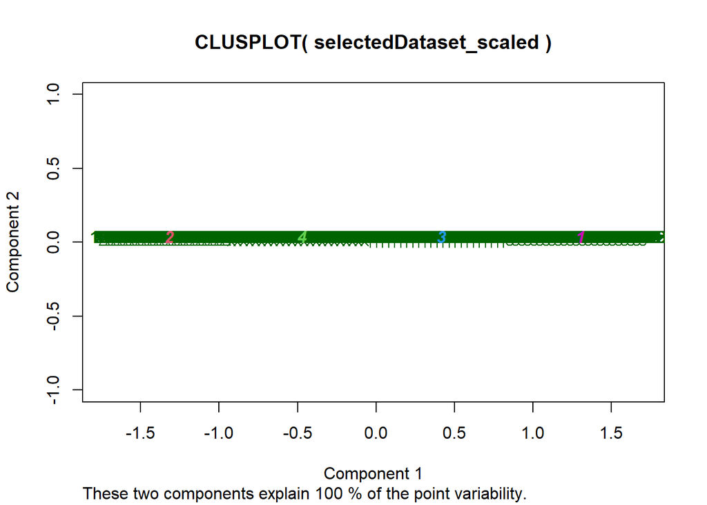

```r
# Visualize clustering using clusplot from the cluster package (additional visualization)
clusplot(selectedDataset_scaled, kmeans_result_selected$cluster, color = TRUE, shade = TRUE, labels = 2, lines = 0)
```

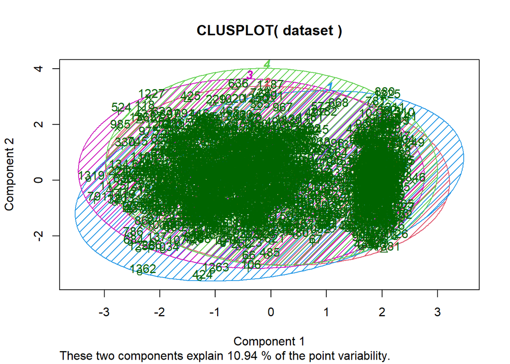

```r
# Visualize clustering using clusplot from the cluster package for the original dataset
clusplot(dataset, kmeans_result_selected$cluster, color = TRUE, shade = TRUE, labels = 2, lines = 0)
```

The results are as follows:

Cluster Sizes: The data is divided into four clusters, with each cluster having a different number of samples. The clusters are labeled as Cluster 1, Cluster 2, Cluster 3, and Cluster 4.

Clustering Vector: The clustering vector assigns each data point to one of the four clusters. This helps visualize how individual data points are grouped into specific clusters.

#### **Second Cluster num_clusters <- 6:**

```r
# Assuming 'originalDataset' is your original dataset
selectedFeatures <- c("Gender", "Epigastric.pain", "Nausea.Vomting", "Jaundice", "ALT.1")

# Create a new dataset with selected features and the class label
selectedDataset <- dataset[, c(selectedFeatures, "Baselinehistological.staging"), drop = FALSE]

# Print the structure of the selected dataset
str(selectedDataset)
```

```
## 'data.frame':    1381 obs. of  6 variables:
##  $ Gender                      : Factor w/ 2 levels "1","2": 1 2 2 2 2 1 1 2 1 2 ...
##  $ Epigastric.pain             : Factor w/ 2 levels "1","2": 1 1 1 2 2 2 2 1 1 2 ...
##  $ Nausea.Vomting              : Factor w/ 2 levels "1","2": 2 2 2 1 1 1 1 1 2 1 ...
##  $ Jaundice                    : Factor w/ 2 levels "1","2": 2 2 2 2 1 1 1 2 1 1 ...
##  $ ALT.1                       : num  1.507 -0.768 0.774 -1.038 1.082 ...
##  $ Baselinehistological.staging: Factor w/ 4 levels "1","2","3","4": 2 3 4 4 3 2 2 2 1 1 ...
```

```r
# Data preprocessing: Select only numeric columns
numeric_columns <- sapply(selectedDataset, is.numeric)
selectedDataset_numeric <- selectedDataset[, numeric_columns]

# Store column names
column_names <- colnames(selectedDataset_numeric)

# Scale the data
selectedDataset_scaled <- scale(selectedDataset_numeric)

# Set the number of clusters (you can change this as needed)
num_clusters <- 6  # Different number of clusters

# Run k-means clustering
set.seed(1234)
kmeans_result_selected <- kmeans(selectedDataset_scaled, num_clusters)

# Print the clustering result
print(kmeans_result_selected)
```

```
## K-means clustering with 6 clusters of sizes 244, 200, 232, 250, 231, 224
##
## Cluster means:
##         [,1]
## 1  0.8602902
## 2 -1.4868063
## 3  0.2432309
## 4 -0.3500717
## 5 -0.9113560
## 6  1.4690270
##
## Clustering vector:
##    [1] 6 5 1 5 1 3 4 6 2 1 5 6 5 1 1 6 6 1 4 3 1 3 1 5 6 6 4 2 1 5 2 6 1 6 2 5 4
##   [38] 4 5 3 2 3 6 4 2 2 1 4 5 3 2 3 5 4 5 2 5 4 5 3 6 5 3 3 1 6 2 6 4 5 1 6 1 5
##   [75] 5 5 1 5 1 4 1 3 6 5 5 1 2 3 4 1 2 1 4 4 2 4 6 4 3 1 3 3 1 1 4 1 1 3 5 5 6
```

[output cut: 44 more lines]

```r
# Calculate Average Silhouette Width
silhouette_avg_selected <- silhouette(kmeans_result_selected$cluster, dist(selectedDataset_scaled))[, 3]
cat("Average Silhouette Width:", mean(silhouette_avg_selected), "\n")
```

```
## Average Silhouette Width: 0.5663067
```

```r
# Calculate Total Within-Cluster Sum of Squares
within_cluster_sum_of_squares_selected <- kmeans_result_selected$tot.withinss
cat("Total Within-Cluster Sum of Squares:", within_cluster_sum_of_squares_selected, "\n")
```

```
## Total Within-Cluster Sum of Squares: 37.6716
```

```r
# Assuming 'cluster_assignments' is your cluster assignments and 'ground_truth_labels' is your ground truth labels
# Modify attribute names according to your dataset
my_cluster_assignments <- kmeans_result_selected$cluster  # Replace 'kmeans_result_selected$cluster' with your actual cluster assignments
my_ground_truth_labels <- sample(1:2, nrow(selectedDataset), replace = TRUE)  # Example: Random ground truth labels

# BCubed Metrics
calculate_bcubed_metrics <- function(cluster_assignments, ground_truth_labels, epsilon = 1e-10) {
  n <- length(cluster_assignments)
  precision_sum <- recall_sum <- 0

  for (i in 1:n) {
    cluster <- cluster_assignments[i]
    label <- ground_truth_labels[i]

    same_category_same_cluster <- sum(ground_truth_labels[cluster_assignments == cluster] == label)
    total_same_cluster <- sum(cluster_assignments == cluster)
    total_same_category <- sum(ground_truth_labels == label)

    # Ensure numerator and denominator are not 0
    precision_sum <- precision_sum + (same_category_same_cluster + epsilon) / (total_same_cluster + epsilon)
    recall_sum <- recall_sum + (same_category_same_cluster + epsilon) / (total_same_category + epsilon)
  }

  precision <- precision_sum / n
  recall <- recall_sum / n

  return(list(precision = precision, recall = recall))
}

# Calculate BCubed Metrics with your data
my_metrics <- calculate_bcubed_metrics(my_cluster_assignments, my_ground_truth_labels)
my_precision <- my_metrics$precision
my_recall <- my_metrics$recall

# Print the BCubed Precision and Recall
cat("BCubed Precision:", my_precision, "\n")
```

```
## BCubed Precision: 0.5023209
```

```r
cat("BCubed Recall:", my_recall, "\n")
```

```
## BCubed Recall: 0.1682521
```

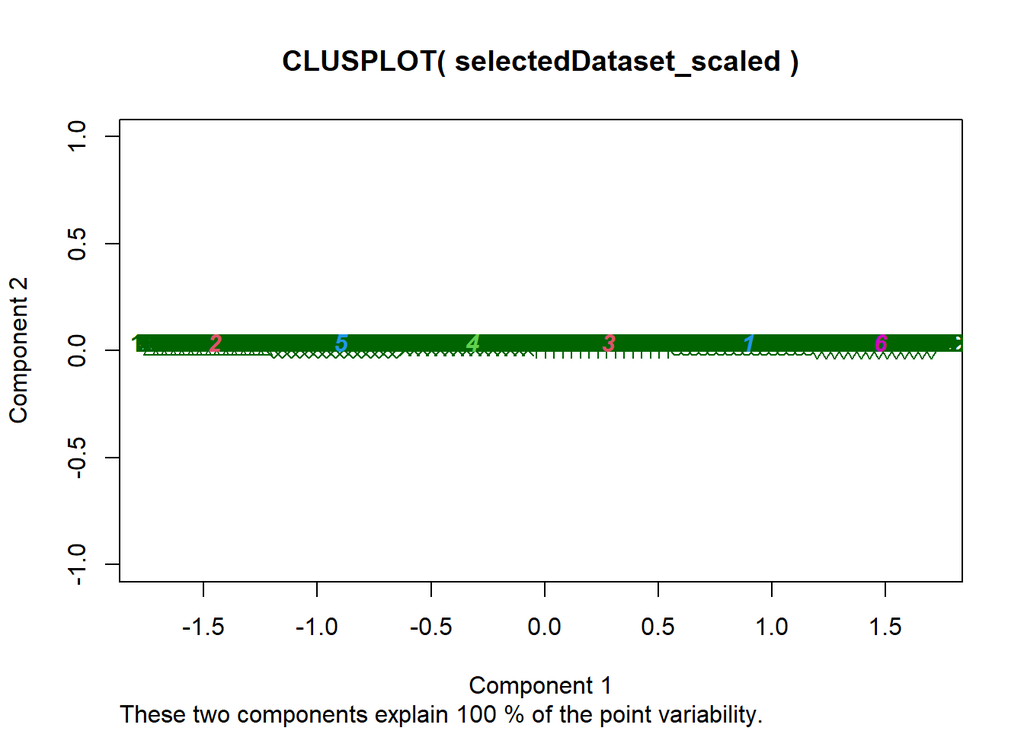

```r
# Visualize clustering using clusplot from the cluster package
clusplot(selectedDataset_scaled, kmeans_result_selected$cluster, color = TRUE, shade = TRUE, labels = 2, lines = 0)
```

```r
# Plot silhouette scores to find the optimal number of clusters
silhouette_scores <- numeric(0)
for (i in 2:10) {
  kmeans_temp <- kmeans(selectedDataset_scaled, centers = i, nstart = 25)
  silhouette_temp <- silhouette(kmeans_temp$cluster, dist(selectedDataset_scaled))[, 3]
  silhouette_scores <- c(silhouette_scores, mean(silhouette_temp))
}

# Plot silhouette scores
plot(2:10, silhouette_scores, type = "b", xlab = "Number of Clusters", ylab = "Average Silhouette Score")
```

[output not shown]